# Objective 1

### Importing Libraries

```python
import pandas as pd
import warnings
warnings.filterwarnings('ignore')
import numpy as np
import matplotlib.pyplot as plt
import statistics as s
import seaborn as sns
from scipy import stats
pd.set_option('display.max_columns', None)
```

### Reading files

#### Reading industry names

```python
sector_name_df= pd.read_csv("sp_500_sector.csv")
del sector_name_df['Unnamed: 0']
sector_name_df=sector_name_df.rename(columns={'Instrument':"Symbol"})
sector_name_df
```

|  | Symbol | GICS Sector Name |
| --- | --- | --- |
| 0 | MMM | Industrials |
| 1 | AOS | Industrials |
| 2 | ABT | Health Care |
| 3 | ABBV.K | Health Care |
| 4 | ABMD.O | Health Care |
| ... | ... | ... |
| 498 | YUM | Consumer Discretionary |
| 499 | ZBRA.O | Information Technology |
| 500 | ZBH | Health Care |
| 501 | ZION.O | Financials |
| 502 | ZTS | Health Care |

503 rows × 2 columns

### Profibility variables

#### ROA (Return on assets )

```python
return_on_assets=pd.read_csv("sp_500_return_on_assets_actual.csv")
del return_on_assets['Unnamed: 0']
cols = ['2021', '2020','2019', '2018', '2017','2016']
return_on_assets.loc[:,cols] = return_on_assets.loc[:,cols].fillna(method='ffill', axis = 1)
return_on_assets.loc[:,cols] = return_on_assets.loc[:,cols].fillna(method='bfill', axis = 1)
return_on_assets = return_on_assets.fillna(0)
return_on_assets=return_on_assets.set_index('Symbol')
return_on_assets =return_on_assets.stack().reset_index()
return_on_assets=return_on_assets.rename(columns={0:"ROA"})
del return_on_assets['level_1']
return_on_assets
```

|  | Symbol | ROA |
| --- | --- | --- |
| 0 | MMM | 12.539 |
| 1 | MMM | 11.060 |
| 2 | MMM | 13.090 |
| 3 | MMM | 16.900 |
| 4 | MMM | 15.850 |
| ... | ... | ... |
| 3013 | ZTS | 14.660 |
| 3014 | ZTS | 15.720 |
| 3015 | ZTS | 15.750 |
| 3016 | ZTS | 14.600 |
| 3017 | ZTS | 12.530 |

3018 rows × 2 columns

#### Return on Equity (ROE)

```python
return_on_equity = pd.read_csv("sp_500_return_on_equity_actual.csv")
del return_on_equity['Unnamed: 0']
cols = ['2021', '2020','2019', '2018', '2017','2016']
return_on_equity.loc[:,cols] = return_on_equity.loc[:,cols].fillna(method='ffill', axis = 1)
return_on_equity.loc[:,cols] = return_on_equity.loc[:,cols].fillna(method='bfill', axis = 1)
return_on_equity = return_on_equity.fillna(0)
return_on_equity=return_on_equity.set_index('Symbol')
return_on_equity =return_on_equity.stack().reset_index()
return_on_equity=return_on_equity.rename(columns={0:"ROE"})
del return_on_equity['level_1']
return_on_equity
```

|  | Symbol | ROE |
| --- | --- | --- |
| 0 | MMM | 42.219 |
| 1 | MMM | 44.130 |
| 2 | MMM | 53.310 |
| 3 | MMM | 58.940 |
| 4 | MMM | 51.170 |
| ... | ... | ... |
| 3013 | ZTS | 50.030 |
| 3014 | ZTS | 71.740 |
| 3015 | ZTS | 77.120 |
| 3016 | ZTS | 72.410 |
| 3017 | ZTS | 76.320 |

3018 rows × 2 columns

#### Return on Investment Capital (ROIC)

```python
return_on_investment_capital = pd.read_csv("sp_500_return_on_invested_capital_actual.csv")
del return_on_investment_capital['Unnamed: 0']
cols = ['2021', '2020','2019', '2018', '2017','2016']
return_on_investment_capital.loc[:,cols] = return_on_investment_capital.loc[:,cols].fillna(method='ffill', axis = 1)
return_on_investment_capital.loc[:,cols] = return_on_investment_capital.loc[:,cols].fillna(method='bfill', axis = 1)
return_on_investment_capital = return_on_investment_capital.fillna(0)
return_on_investment_capital=return_on_investment_capital.set_index('Symbol')
return_on_investment_capital =return_on_investment_capital.stack().reset_index()
return_on_investment_capital=return_on_investment_capital.rename(columns={0:"ROIC"})
del return_on_investment_capital['level_1']
return_on_investment_capital
```

|  | Symbol | ROIC |
| --- | --- | --- |
| 0 | MMM | 20.750 |
| 1 | MMM | 20.750 |
| 2 | MMM | 20.820 |
| 3 | MMM | 30.740 |
| 4 | MMM | 27.530 |
| ... | ... | ... |
| 3013 | ZTS | 28.310 |
| 3014 | ZTS | 26.870 |
| 3015 | ZTS | 29.960 |
| 3016 | ZTS | 35.227 |
| 3017 | ZTS | 29.810 |

3018 rows × 2 columns

#### EBITDA

```python
ebitda = pd.read_csv("sp_500_ebitda.csv")
del ebitda['Unnamed: 0']
cols = ['2021', '2020','2019', '2018', '2017','2016']
ebitda.loc[:,cols] = ebitda.loc[:,cols].fillna(method='ffill', axis = 1)
ebitda.loc[:,cols] = ebitda.loc[:,cols].fillna(method='bfill', axis = 1)
ebitda = ebitda.fillna(0)
ebitda=ebitda.set_index('Symbol')
ebitda =ebitda.stack().reset_index()
ebitda=ebitda.rename(columns={0:"EBITDA"})
del ebitda['level_1']
ebitda
```

|  | Symbol | EBITDA |
| --- | --- | --- |
| 0 | MMM | 9.408000e+09 |
| 1 | MMM | 8.941000e+09 |
| 2 | MMM | 8.661000e+09 |
| 3 | MMM | 8.283000e+09 |
| 4 | MMM | 8.742000e+09 |
| ... | ... | ... |
| 3013 | ZTS | 2.736000e+09 |
| 3014 | ZTS | 2.446000e+09 |
| 3015 | ZTS | 2.232000e+09 |
| 3016 | ZTS | 1.993000e+09 |
| 3017 | ZTS | 1.677000e+09 |

3018 rows × 2 columns

### Equity Variables

#### Diluted earnings per share (EPS)

```python
eps=pd.read_csv("sp_500_diluted_eps.csv")
del eps['Unnamed: 0']
cols = ['2021', '2020','2019', '2018', '2017','2016']
eps.loc[:,cols] = eps.loc[:,cols].fillna(method='ffill', axis = 1)
eps.loc[:,cols] = eps.loc[:,cols].fillna(method='bfill', axis = 1)
eps = eps.fillna(0)
eps=eps.set_index('Symbol')
eps =eps.stack().reset_index()
eps=eps.rename(columns={0:"EPS"})
del eps['level_1']
eps
```

|  | Symbol | EPS |
| --- | --- | --- |
| 0 | MMM | 10.11618 |
| 1 | MMM | 9.35933 |
| 2 | MMM | 7.72005 |
| 3 | MMM | 8.88538 |
| 4 | MMM | 7.92884 |
| ... | ... | ... |
| 3013 | ZTS | 3.42270 |
| 3014 | ZTS | 3.11341 |
| 3015 | ZTS | 2.93285 |
| 3016 | ZTS | 1.75196 |
| 3017 | ZTS | 1.64785 |

3018 rows × 2 columns

#### Dividend per Share (DPS)

```python
dps= pd.read_csv("sp_500_dividend_per_share.csv")
del dps['Unnamed: 0']
cols = ['2021', '2020','2019', '2018', '2017','2016']
dps.loc[:,cols] = dps.loc[:,cols].fillna(method='ffill', axis = 1)
dps.loc[:,cols] = dps.loc[:,cols].fillna(method='bfill', axis = 1)
dps = dps.fillna(0)
dps=dps.set_index('Symbol')
dps =dps.stack().reset_index()
dps=dps.rename(columns={0:"DPS"})
del dps['level_1']
dps
```

|  | Symbol | DPS |
| --- | --- | --- |
| 0 | MMM | 5.920 |
| 1 | MMM | 5.880 |
| 2 | MMM | 5.760 |
| 3 | MMM | 5.440 |
| 4 | MMM | 4.700 |
| ... | ... | ... |
| 3013 | ZTS | 0.800 |
| 3014 | ZTS | 0.660 |
| 3015 | ZTS | 0.542 |
| 3016 | ZTS | 0.441 |
| 3017 | ZTS | 0.390 |

3018 rows × 2 columns

#### Dividend Yield (DY)

```python
DY= pd.read_csv("sp_500_dividend_yield.csv")
del DY['Unnamed: 0']
cols = ['2021', '2020','2019', '2018', '2017','2016']
DY.loc[:,cols] = DY.loc[:,cols].fillna(method='ffill', axis = 1)
DY.loc[:,cols] = DY.loc[:,cols].fillna(method='bfill', axis = 1)
DY = DY.fillna(0)
DY=DY.set_index('Symbol')
DY =DY.stack().reset_index()
DY=DY.rename(columns={0:"DY"})
del DY['level_1']
DY
```

|  | Symbol | DY |
| --- | --- | --- |
| 0 | MMM | 3.332770 |
| 1 | MMM | 3.364037 |
| 2 | MMM | 3.264936 |
| 3 | MMM | 2.855044 |
| 4 | MMM | 1.996856 |
| ... | ... | ... |
| 3013 | ZTS | 0.604230 |
| 3014 | ZTS | 0.604458 |
| 3015 | ZTS | 0.766893 |
| 3016 | ZTS | 0.699611 |
| 3017 | ZTS | 0.699611 |

3018 rows × 2 columns

#### Price to earning ratio (PER)

```python
per= pd.read_csv("sp_500_pe.csv")
del per['Unnamed: 0']
cols = ['2021', '2020','2019', '2018', '2017','2016']
per.loc[:,cols] = per.loc[:,cols].fillna(method='ffill', axis = 1)
per.loc[:,cols] = per.loc[:,cols].fillna(method='bfill', axis = 1)
per = per.fillna(0)
per=per.set_index('Symbol')
per =per.stack().reset_index()
per=per.rename(columns={0:"PER"})
del per['level_1']
per
```

|  | Symbol | PER |
| --- | --- | --- |
| 0 | MMM | 17.396337 |
| 1 | MMM | 20.285993 |
| 2 | MMM | 21.113857 |
| 3 | MMM | 20.975434 |
| 4 | MMM | 26.272814 |
| ... | ... | ... |
| 3013 | ZTS | 47.521011 |
| 3014 | ZTS | 43.347253 |
| 3015 | ZTS | 31.701089 |
| 3016 | ZTS | 37.997985 |
| 3017 | ZTS | 38.749140 |

3018 rows × 2 columns

#### Enterprise Value (EV)

```python
EV= pd.read_csv("sp_500_enterprise_value.csv")
del EV['Unnamed: 0']
cols = ['2021', '2020','2019', '2018', '2017','2016']
EV.loc[:,cols] = EV.loc[:,cols].fillna(method='ffill', axis = 1)
EV.loc[:,cols] = EV.loc[:,cols].fillna(method='bfill', axis = 1)
EV = EV.fillna(0)
EV=EV.set_index('Symbol')
EV =EV.stack().reset_index()
EV=EV.rename(columns={0:"EV"})
del EV['level_1']
EV
```

|  | Symbol | EV |
| --- | --- | --- |
| 0 | MMM | 1.140789e+11 |
| 1 | MMM | 1.159227e+11 |
| 2 | MMM | 1.133481e+11 |
| 3 | MMM | 1.212466e+11 |
| 4 | MMM | 1.484903e+11 |
| ... | ... | ... |
| 3013 | ZTS | 8.270682e+10 |
| 3014 | ZTS | 6.766221e+10 |
| 3015 | ZTS | 4.614777e+10 |
| 3016 | ZTS | 3.885525e+10 |
| 3017 | ZTS | 3.026386e+10 |

3018 rows × 2 columns

#### Price to sales per share ratio

```python
price_to_sales= pd.read_csv("sp_500_price_to_sale_per_share.csv")
del price_to_sales['Unnamed: 0']
cols = ['2021', '2020','2019', '2018', '2017','2016']
price_to_sales.loc[:,cols] = price_to_sales.loc[:,cols].fillna(method='ffill', axis = 1)
price_to_sales.loc[:,cols] = price_to_sales.loc[:,cols].fillna(method='bfill', axis = 1)
price_to_sales = price_to_sales.fillna(0)
price_to_sales=price_to_sales.set_index('Symbol')
price_to_sales =price_to_sales.stack().reset_index()
price_to_sales=price_to_sales.rename(columns={0:"PTS"})
del price_to_sales['level_1']
price_to_sales
```

|  | Symbol | PTS |
| --- | --- | --- |
| 0 | MMM | 2.875415 |
| 1 | MMM | 3.179323 |
| 2 | MMM | 3.174042 |
| 3 | MMM | 3.348389 |
| 4 | MMM | 4.522786 |
| ... | ... | ... |
| 3013 | ZTS | 12.023360 |
| 3014 | ZTS | 10.250115 |
| 3015 | ZTS | 7.183669 |
| 3016 | ZTS | 6.850946 |
| 3017 | ZTS | 5.411434 |

3018 rows × 2 columns

#### Price to book value (PBV)

```python
pbv= pd.read_csv("sp_500_price_to_book_per_share.csv")
del pbv['Unnamed: 0']
cols = ['2021', '2020','2019', '2018', '2017','2016']
pbv.loc[:,cols] = pbv.loc[:,cols].fillna(method='ffill', axis = 1)
pbv.loc[:,cols] = pbv.loc[:,cols].fillna(method='bfill', axis = 1)
pbv = pbv.fillna(0)
pbv=pbv.set_index('Symbol')
pbv =pbv.stack().reset_index()
pbv=pbv.rename(columns={0:"PBV"})
del pbv['level_1']
pbv
```

|  | Symbol | PBV |
| --- | --- | --- |
| 0 | MMM | 7.078823 |
| 1 | MMM | 8.486759 |
| 2 | MMM | 9.479577 |
| 3 | MMM | 10.826404 |
| 4 | MMM | 11.541930 |
| ... | ... | ... |
| 3013 | ZTS | 21.835833 |
| 3014 | ZTS | 23.561354 |
| 3015 | ZTS | 19.425430 |
| 3016 | ZTS | 17.668888 |
| 3017 | ZTS | 16.691930 |

3018 rows × 2 columns

### ESG SCORES

```python
esg_scores= pd.read_csv("sp_500_esg_scores_2016_to_2021.csv")
del esg_scores['Unnamed: 0']
esg_scores=esg_scores.rename(columns={'Instrument':"Symbol"})
cols = ['2021', '2020','2019', '2018', '2017','2016']
esg_scores.loc[:,cols] = esg_scores.loc[:,cols].fillna(method='ffill', axis = 1)
esg_scores.loc[:,cols] = esg_scores.loc[:,cols].fillna(method='bfill', axis = 1)
esg_scores = esg_scores.fillna(0)
esg_scores
```

|  | Symbol | 2021 | 2020 | 2019 | 2018 | 2017 | 2016 |
| --- | --- | --- | --- | --- | --- | --- | --- |
| 0 | MMM | 89.862822 | 92.732718 | 88.540146 | 85.984531 | 87.233512 | 88.128389 |
| 1 | AOS | 53.966301 | 53.966301 | 53.695534 | 41.063622 | 40.234916 | 39.338609 |
| 2 | ABT | 82.203654 | 82.965995 | 80.952100 | 77.683987 | 81.993237 | 79.345189 |
| 3 | ABBV.K | 82.819108 | 81.510916 | 78.774658 | 75.537190 | 79.487007 | 75.116025 |
| 4 | ABMD.O | 25.963587 | 25.319605 | 20.890800 | 20.548131 | 25.892601 | 21.013227 |
| ... | ... | ... | ... | ... | ... | ... | ... |
| 498 | YUM | 77.756865 | 78.144823 | 72.703976 | 82.363311 | 78.807757 | 64.074647 |
| 499 | ZBRA.O | 42.941130 | 42.941130 | 33.306346 | 24.933099 | 29.382888 | 26.308357 |
| 500 | ZBH | 68.032669 | 62.925379 | 63.744334 | 45.582277 | 40.606044 | 45.966653 |
| 501 | ZION.O | 51.913269 | 54.258814 | 45.462987 | 38.087569 | 35.879043 | 35.764204 |
| 502 | ZTS | 67.775598 | 65.292733 | 59.522098 | 58.928305 | 51.070515 | 45.265223 |

503 rows × 7 columns

```python
esg_scores=esg_scores.set_index('Symbol')
esg_scores =esg_scores.stack().reset_index()
esg_scores=esg_scores.rename(columns={0:"ESG Score"})
del esg_scores['level_1']
sector_name_df=sector_name_df.loc[sector_name_df.index.repeat(6)].reset_index(drop=True)
del esg_scores['Symbol']
esg_scores=pd.concat([sector_name_df,esg_scores], axis=1)
esg_scores
```

|  | Symbol | GICS Sector Name | ESG Score |
| --- | --- | --- | --- |
| 0 | MMM | Industrials | 89.862822 |
| 1 | MMM | Industrials | 92.732718 |
| 2 | MMM | Industrials | 88.540146 |
| 3 | MMM | Industrials | 85.984531 |
| 4 | MMM | Industrials | 87.233512 |
| ... | ... | ... | ... |
| 3013 | ZTS | Health Care | 65.292733 |
| 3014 | ZTS | Health Care | 59.522098 |
| 3015 | ZTS | Health Care | 58.928305 |
| 3016 | ZTS | Health Care | 51.070515 |
| 3017 | ZTS | Health Care | 45.265223 |

3018 rows × 3 columns

# Finding Correlation for Profitability Variables

### Merging the dataframe based on symbols

```python
pdList=[esg_scores,return_on_assets,return_on_equity,return_on_investment_capital,ebitda]
prof_var_ls=['ESG Score','ROA','ROE','ROIC','EBITDA']

del return_on_assets['Symbol']
del return_on_equity['Symbol']
del return_on_investment_capital['Symbol']
del ebitda['Symbol']
prof_variables_df=pd.concat(pdList, axis=1)
for i in prof_var_ls:
    prof_variables_df=prof_variables_df[prof_variables_df[i] != 0]
```

```python
prof_variables_df
```

|  | Symbol | GICS Sector Name | ESG Score | ROA | ROE | ROIC | EBITDA |
| --- | --- | --- | --- | --- | --- | --- | --- |
| 0 | MMM | Industrials | 89.862822 | 12.539 | 42.219 | 20.750 | 9.408000e+09 |
| 1 | MMM | Industrials | 92.732718 | 11.060 | 44.130 | 20.750 | 8.941000e+09 |
| 2 | MMM | Industrials | 88.540146 | 13.090 | 53.310 | 20.820 | 8.661000e+09 |
| 3 | MMM | Industrials | 85.984531 | 16.900 | 58.940 | 30.740 | 8.283000e+09 |
| 4 | MMM | Industrials | 87.233512 | 15.850 | 51.170 | 27.530 | 8.742000e+09 |
| ... | ... | ... | ... | ... | ... | ... | ... |
| 3013 | ZTS | Health Care | 65.292733 | 14.660 | 50.030 | 28.310 | 2.736000e+09 |
| 3014 | ZTS | Health Care | 59.522098 | 15.720 | 71.740 | 26.870 | 2.446000e+09 |
| 3015 | ZTS | Health Care | 58.928305 | 15.750 | 77.120 | 29.960 | 2.232000e+09 |
| 3016 | ZTS | Health Care | 51.070515 | 14.600 | 72.410 | 35.227 | 1.993000e+09 |
| 3017 | ZTS | Health Care | 45.265223 | 12.530 | 76.320 | 29.810 | 1.677000e+09 |

2640 rows × 7 columns

### Separating sectors into separate DFs

```python
communication_services_df = prof_variables_df[prof_variables_df['GICS Sector Name'] == 'Communication Services']
communication_services_df
```

|  | Symbol | GICS Sector Name | ESG Score | ROA | ROE | ROIC | EBITDA |
| --- | --- | --- | --- | --- | --- | --- | --- |
| 36 | ATVI.O | Communication Services | 67.716040 | 12.109 | 17.87 | 28.210 | 3.793000e+09 |
| 37 | ATVI.O | Communication Services | 63.640830 | 11.690 | 19.40 | 33.647 | 3.288000e+09 |
| 38 | ATVI.O | Communication Services | 59.539460 | 9.200 | 14.35 | 17.650 | 2.308000e+09 |
| 39 | ATVI.O | Communication Services | 51.782054 | 10.970 | 19.24 | 21.160 | 3.008000e+09 |
| 40 | ATVI.O | Communication Services | 43.986182 | 9.680 | 18.83 | 26.239 | 2.512000e+09 |
| ... | ... | ... | ... | ... | ... | ... | ... |
| 2887 | WBD.O | Communication Services | 50.516305 | 6.340 | 21.13 | 12.600 | 7.061000e+09 |
| 2888 | WBD.O | Communication Services | 48.766010 | 7.919 | 28.71 | 12.600 | 7.364000e+09 |
| 2889 | WBD.O | Communication Services | 42.684188 | 5.280 | 22.38 | 12.600 | 7.286000e+09 |
| 2890 | WBD.O | Communication Services | 35.969380 | 5.730 | 22.40 | 15.700 | 4.391000e+09 |
| 2891 | WBD.O | Communication Services | 35.590046 | 7.550 | 22.49 | 12.550 | 4.148000e+09 |

144 rows × 7 columns

```python
consumer_discretionary_df = prof_variables_df[prof_variables_df['GICS Sector Name'] == 'Consumer Discretionary']
consumer_discretionary_df
```

|  | Symbol | GICS Sector Name | ESG Score | ROA | ROE | ROIC | EBITDA |
| --- | --- | --- | --- | --- | --- | --- | --- |
| 60 | AAP | Consumer Discretionary | 66.278673 | 6.45 | 23.199 | 22.700 | 1.162860e+09 |
| 61 | AAP | Consumer Discretionary | 57.843157 | 5.09 | 16.520 | 16.980 | 1.050015e+09 |
| 62 | AAP | Consumer Discretionary | 43.227957 | 5.75 | 16.430 | 15.780 | 9.928830e+08 |
| 63 | AAP | Consumer Discretionary | 62.966926 | 6.02 | 15.150 | 15.890 | 8.980750e+08 |
| 64 | AAP | Consumer Discretionary | 54.873090 | 4.74 | 12.580 | 17.541 | 8.245120e+08 |
| ... | ... | ... | ... | ... | ... | ... | ... |
| 2989 | YUM | Consumer Discretionary | 78.144823 | 20.10 | -14.010 | 74.620 | 1.931000e+09 |
| 2990 | YUM | Consumer Discretionary | 72.703976 | 23.74 | -13.940 | 85.830 | 2.086000e+09 |
| 2991 | YUM | Consumer Discretionary | 82.363311 | 22.07 | -14.610 | 80.850 | 1.959000e+09 |
| 2992 | YUM | Consumer Discretionary | 78.807757 | 19.50 | -17.550 | 77.820 | 1.940000e+09 |
| 2993 | YUM | Consumer Discretionary | 64.074647 | 14.48 | -41.300 | 47.560 | 1.847000e+09 |

330 rows × 7 columns

```python
consumer_staples_df = prof_variables_df[prof_variables_df['GICS Sector Name'] == 'Consumer Staples']
consumer_staples_df
```

|  | Symbol | GICS Sector Name | ESG Score | ROA | ROE | ROIC | EBITDA |
| --- | --- | --- | --- | --- | --- | --- | --- |
| 42 | ADM | Consumer Staples | 83.618037 | 8.47 | 13.80 | 8.000 | 3.975000e+09 |
| 43 | ADM | Consumer Staples | 83.947377 | 6.21 | 10.29 | 5.930 | 2.762000e+09 |
| 44 | ADM | Consumer Staples | 80.860552 | 4.85 | 7.77 | 8.900 | 2.658000e+09 |
| 45 | ADM | Consumer Staples | 76.270645 | 6.83 | 10.62 | 7.896 | 2.957000e+09 |
| 46 | ADM | Consumer Staples | 78.708707 | 3.49 | 7.84 | 4.370 | 2.464000e+09 |
| ... | ... | ... | ... | ... | ... | ... | ... |
| 2881 | WMT | Consumer Staples | 81.944964 | 6.47 | 20.28 | 15.240 | 3.814800e+10 |
| 2882 | WMT | Consumer Staples | 81.942940 | 6.20 | 19.21 | 13.030 | 3.196800e+10 |
| 2883 | WMT | Consumer Staples | 73.651127 | 6.83 | 19.23 | 11.400 | 3.265700e+10 |
| 2884 | WMT | Consumer Staples | 76.554479 | 6.59 | 17.07 | 13.270 | 3.096600e+10 |
| 2885 | WMT | Consumer Staples | 78.117771 | 7.20 | 16.99 | 19.330 | 3.284400e+10 |

198 rows × 7 columns

```python
energy_df = prof_variables_df[prof_variables_df['GICS Sector Name'] == 'Energy']
energy_df
```

|  | Symbol | GICS Sector Name | ESG Score | ROA | ROE | ROIC | EBITDA |
| --- | --- | --- | --- | --- | --- | --- | --- |
| 264 | APA.O | Energy | 65.477919 | 11.220 | -90.40 | 7.700 | 4.083000e+09 |
| 265 | APA.O | Energy | 62.979780 | -2.640 | -50.37 | 0.110 | 1.982000e+09 |
| 266 | APA.O | Energy | 57.819646 | 0.040 | 0.15 | 5.750 | 3.690000e+09 |
| 267 | APA.O | Energy | 58.818313 | 3.120 | 9.34 | 5.750 | 4.535000e+09 |
| 268 | APA.O | Energy | 48.621164 | 0.410 | 1.35 | 5.750 | 3.083000e+09 |
| ... | ... | ... | ... | ... | ... | ... | ... |
| 2953 | WMB | Energy | 72.108091 | 1.840 | 6.62 | 5.500 | 4.292000e+09 |
| 2954 | WMB | Energy | 75.266542 | 2.629 | 8.56 | 5.654 | 4.101000e+09 |
| 2955 | WMB | Energy | 63.950113 | 1.690 | 6.37 | 6.900 | 3.699000e+09 |
| 2956 | WMB | Energy | 51.111792 | 1.690 | 10.99 | 3.190 | 3.490000e+09 |
| 2957 | WMB | Energy | 55.046553 | -0.880 | -7.77 | 1.870 | 3.325000e+09 |

132 rows × 7 columns

```python
financials_df= prof_variables_df[prof_variables_df['GICS Sector Name'] == 'Financials']
financials_df
```

|  | Symbol | GICS Sector Name | ESG Score | ROA | ROE | ROIC | EBITDA |
| --- | --- | --- | --- | --- | --- | --- | --- |
| 258 | AON | Financials | 59.996542 | 8.48 | 119.140 | 31.40 | 3.852000e+09 |
| 259 | AON | Financials | 58.368696 | 7.44 | 66.580 | 37.18 | 3.317000e+09 |
| 260 | AON | Financials | 58.201736 | 7.91 | 58.650 | 25.48 | 3.197000e+09 |
| 261 | AON | Financials | 49.271291 | 7.68 | 45.830 | 24.06 | 2.785000e+09 |
| 262 | AON | Financials | 50.033578 | 7.68 | 33.800 | 21.77 | 1.956000e+09 |
| ... | ... | ... | ... | ... | ... | ... | ... |
| 2959 | WTW.O | Financials | 65.187852 | 4.11 | 14.460 | 11.20 | 1.827000e+09 |
| 2960 | WTW.O | Financials | 50.436486 | 4.20 | 14.199 | 9.68 | 1.795000e+09 |
| 2961 | WTW.O | Financials | 45.582992 | 3.96 | 12.850 | 12.59 | 1.782000e+09 |
| 2962 | WTW.O | Financials | 45.968212 | 3.68 | 11.750 | 12.82 | 1.750000e+09 |
| 2963 | WTW.O | Financials | 41.092719 | 4.47 | 18.030 | 12.40 | 1.487000e+09 |

108 rows × 7 columns

```python
health_care_df= prof_variables_df[prof_variables_df['GICS Sector Name'] == 'Health Care']
health_care_df
```

|  | Symbol | GICS Sector Name | ESG Score | ROA | ROE | ROIC | EBITDA |
| --- | --- | --- | --- | --- | --- | --- | --- |
| 12 | ABT | Health Care | 82.203654 | 12.680 | 27.310 | 21.700 | 1.212600e+10 |
| 13 | ABT | Health Care | 82.965995 | 9.330 | 20.519 | 21.700 | 8.757000e+09 |
| 14 | ABT | Health Care | 80.952100 | 8.599 | 18.859 | 8.539 | 7.684000e+09 |
| 15 | ABT | Health Care | 77.683987 | 7.150 | 16.710 | 12.360 | 7.008000e+09 |
| 16 | ABT | Health Care | 81.993237 | 6.830 | 17.110 | 12.090 | 4.892000e+09 |
| ... | ... | ... | ... | ... | ... | ... | ... |
| 3013 | ZTS | Health Care | 65.292733 | 14.660 | 50.030 | 28.310 | 2.736000e+09 |
| 3014 | ZTS | Health Care | 59.522098 | 15.720 | 71.740 | 26.870 | 2.446000e+09 |
| 3015 | ZTS | Health Care | 58.928305 | 15.750 | 77.120 | 29.960 | 2.232000e+09 |
| 3016 | ZTS | Health Care | 51.070515 | 14.600 | 72.410 | 35.227 | 1.993000e+09 |
| 3017 | ZTS | Health Care | 45.265223 | 12.530 | 76.320 | 29.810 | 1.677000e+09 |

366 rows × 7 columns

```python
industrials_df= prof_variables_df[prof_variables_df['GICS Sector Name'] == 'Industrials']
industrials_df
```

|  | Symbol | GICS Sector Name | ESG Score | ROA | ROE | ROIC | EBITDA |
| --- | --- | --- | --- | --- | --- | --- | --- |
| 0 | MMM | Industrials | 89.862822 | 12.539 | 42.219 | 20.750 | 9.408000e+09 |
| 1 | MMM | Industrials | 92.732718 | 11.060 | 44.130 | 20.750 | 8.941000e+09 |
| 2 | MMM | Industrials | 88.540146 | 13.090 | 53.310 | 20.820 | 8.661000e+09 |
| 3 | MMM | Industrials | 85.984531 | 16.900 | 58.940 | 30.740 | 8.283000e+09 |
| 4 | MMM | Industrials | 87.233512 | 15.850 | 51.170 | 27.530 | 8.742000e+09 |
| ... | ... | ... | ... | ... | ... | ... | ... |
| 2983 | XYL | Industrials | 82.684210 | 4.540 | 12.620 | 10.780 | 8.370000e+08 |
| 2984 | XYL | Industrials | 76.885450 | 7.330 | 19.110 | 13.140 | 1.126000e+09 |
| 2985 | XYL | Industrials | 73.763471 | 3.340 | 10.830 | 14.894 | 9.370000e+08 |
| 2986 | XYL | Industrials | 77.157672 | 6.490 | 18.450 | 14.630 | 8.110000e+08 |
| 2987 | XYL | Industrials | 70.321177 | 6.540 | 17.030 | 12.020 | 5.870000e+08 |

426 rows × 7 columns

```python
information_technology_df= prof_variables_df[prof_variables_df['GICS Sector Name'] == 'Information Technology']
information_technology_df
```

|  | Symbol | GICS Sector Name | ESG Score | ROA | ROE | ROIC | EBITDA |
| --- | --- | --- | --- | --- | --- | --- | --- |
| 30 | ACN | Information Technology | 80.688107 | 15.22 | 33.07 | 48.030 | 1.039783e+10 |
| 31 | ACN | Information Technology | 78.264807 | 14.16 | 31.12 | 48.800 | 8.446286e+09 |
| 32 | ACN | Information Technology | 77.511350 | 14.67 | 31.23 | 54.417 | 7.235362e+09 |
| 33 | ACN | Information Technology | 77.801686 | 19.31 | 35.29 | 72.300 | 6.923020e+09 |
| 34 | ACN | Information Technology | 82.172466 | 18.72 | 45.70 | 74.710 | 6.492437e+09 |
| ... | ... | ... | ... | ... | ... | ... | ... |
| 2995 | ZBRA.O | Information Technology | 42.941130 | 13.68 | 34.65 | 24.560 | 8.310000e+08 |
| 2996 | ZBRA.O | Information Technology | 33.306346 | 15.60 | 44.49 | 24.890 | 8.990000e+08 |
| 2997 | ZBRA.O | Information Technology | 24.933099 | 13.88 | 55.14 | 24.890 | 8.040000e+08 |
| 2998 | ZBRA.O | Information Technology | 29.382888 | 8.51 | 46.62 | 24.890 | 6.510000e+08 |
| 2999 | ZBRA.O | Information Technology | 26.308357 | 6.06 | 34.78 | 24.890 | 5.900000e+08 |

432 rows × 7 columns

```python
materials_df= prof_variables_df[prof_variables_df['GICS Sector Name'] == 'Materials']
materials_df
```

|  | Symbol | GICS Sector Name | ESG Score | ROA | ROE | ROIC | EBITDA |
| --- | --- | --- | --- | --- | --- | --- | --- |
| 84 | APD | Materials | 81.631560 | 8.570 | 16.590 | 10.590 | 3.750700e+09 |
| 85 | APD | Materials | 81.631560 | 7.710 | 15.669 | 14.241 | 3.589100e+09 |
| 86 | APD | Materials | 80.268096 | 7.400 | 15.410 | 12.530 | 3.388800e+09 |
| 87 | APD | Materials | 85.139446 | 9.550 | 16.609 | 13.974 | 3.251800e+09 |
| 88 | APD | Materials | 78.934903 | 8.740 | 15.710 | 16.160 | 2.937100e+09 |
| ... | ... | ... | ... | ... | ... | ... | ... |
| 2935 | WRK | Materials | 71.313374 | 3.129 | 8.140 | 6.000 | 2.700600e+09 |
| 2936 | WRK | Materials | 64.462161 | 2.430 | 6.430 | 5.520 | 3.189200e+09 |
| 2937 | WRK | Materials | 60.138822 | 3.710 | 8.910 | 11.199 | 2.791400e+09 |
| 2938 | WRK | Materials | 56.351678 | 4.210 | 9.740 | 7.600 | 2.143500e+09 |
| 2939 | WRK | Materials | 52.466261 | 2.790 | 6.680 | 12.030 | 1.943200e+09 |

168 rows × 7 columns

```python
real_estate_df= prof_variables_df[prof_variables_df['GICS Sector Name'] == 'Real Estate']
real_estate_df
```

|  | Symbol | GICS Sector Name | ESG Score | ROA | ROE | ROIC | EBITDA |
| --- | --- | --- | --- | --- | --- | --- | --- |
| 204 | AMT | Real Estate | 81.093139 | 4.379 | 55.969 | 5.700 | 7.964300e+09 |
| 205 | AMT | Real Estate | 69.283275 | 3.760 | 36.960 | 8.590 | 6.718200e+09 |
| 206 | AMT | Real Estate | 71.835503 | 4.980 | 36.329 | 9.590 | 4.723900e+09 |
| 207 | AMT | Real Estate | 73.605231 | 3.710 | 21.200 | 7.370 | 4.114800e+09 |
| 208 | AMT | Real Estate | 61.315020 | 3.990 | 19.660 | 7.960 | 3.802700e+09 |
| ... | ... | ... | ... | ... | ... | ... | ... |
| 2941 | WY | Real Estate | 77.613142 | 5.880 | 11.380 | 11.660 | 2.083000e+09 |
| 2942 | WY | Real Estate | 68.308558 | 1.690 | 3.310 | 5.370 | 1.254000e+09 |
| 2943 | WY | Real Estate | 72.246953 | 5.050 | 9.930 | 9.259 | 1.904000e+09 |
| 2944 | WY | Real Estate | 81.061767 | 4.680 | 9.650 | 10.097 | 1.708000e+09 |
| 2945 | WY | Real Estate | 76.574265 | 3.370 | 7.600 | 10.097 | 1.515000e+09 |

162 rows × 7 columns

```python
utilities_df= prof_variables_df[prof_variables_df['GICS Sector Name'] == 'Utilities']
utilities_df
```

|  | Symbol | GICS Sector Name | ESG Score | ROA | ROE | ROIC | EBITDA |
| --- | --- | --- | --- | --- | --- | --- | --- |
| 66 | AES | Utilities | 71.111716 | 4.200 | 52.210 | 7.299 | 3.700000e+09 |
| 67 | AES | Utilities | 71.111716 | 3.649 | 44.299 | 6.099 | 3.594000e+09 |
| 68 | AES | Utilities | 69.619695 | 3.750 | 39.969 | 8.430 | 3.203000e+09 |
| 69 | AES | Utilities | 65.723051 | 3.610 | 41.780 | 5.500 | 3.396000e+09 |
| 70 | AES | Utilities | 60.703987 | 2.940 | 38.910 | 10.249 | 3.467000e+09 |
| ... | ... | ... | ... | ... | ... | ... | ... |
| 2977 | XEL.O | Utilities | 81.804921 | 2.819 | 10.589 | 6.010 | 4.198000e+09 |
| 2978 | XEL.O | Utilities | 88.273393 | 2.850 | 10.779 | 4.799 | 4.015000e+09 |
| 2979 | XEL.O | Utilities | 77.489031 | 2.830 | 11.250 | 4.730 | 3.750000e+09 |
| 2980 | XEL.O | Utilities | 72.491851 | 2.020 | 10.800 | 4.170 | 3.838000e+09 |
| 2981 | XEL.O | Utilities | 73.655286 | 2.810 | 10.390 | 8.590 | 3.683734e+09 |

174 rows × 7 columns

### Getting correlation and p-value

```python
industries=['Communication Services', 'Consumer Discretionary', 'Consumer Staples',
       'Energy', 'Financials', 'Health Care', 'Industrials',
       'Information Technology', 'Materials', 'Real Estate', 'Utilities']
prof_var_ls=['ROA','ROE','ROIC','EBITDA']
prof_var_corr_ls=['ROA_corr','ROE_corr','ROIC_corr','EBITDA_corr']
prof_var_p_ls=['ROA_p','ROE_p','ROIC_p','EBITDA_p']
sector_df=[communication_services_df, consumer_discretionary_df, consumer_staples_df,energy_df, financials_df,
          health_care_df,industrials_df,information_technology_df,materials_df,real_estate_df,utilities_df]

prof_var_corr_df = pd.DataFrame()
prof_var_corr_df['GICS Sector Names']=industries
prof_var_corr_df=prof_var_corr_df.set_index('GICS Sector Names')
prof_var_corr_df[["ROA_corr","ROE_corr","ROIC_corr","EBITDA_corr"]]=None
prof_var_corr_df[['ROA_p','ROE_p','ROIC_p','EBITDA_p']]=None
for j in range(11):
    for i in range(4):
        prof_var_corr_df.loc[industries[j]][prof_var_corr_ls[i]]=sector_df[j]['ESG Score'].corr(sector_df[j][prof_var_ls[i]])
        prof_var_corr_df.loc[industries[j]][prof_var_p_ls[i]]=(stats.pearsonr(sector_df[j]['ESG Score'],sector_df[j][prof_var_ls[i]]))[1]
prof_var_corr_df
```

| GICS Sector Names | ROA_corr | ROE_corr | ROIC_corr | EBITDA_corr | ROA_p | ROE_p | ROIC_p | EBITDA_p |
| --- | --- | --- | --- | --- | --- | --- | --- | --- |
| Communication Services | 0.092106 | 0.013049 | 0.022951 | 0.528027 | 0.272218 | 0.876636 | 0.784819 | 0.0 |
| Consumer Discretionary | -0.092691 | -0.052935 | 0.066968 | 0.394718 | 0.092754 | 0.33774 | 0.225023 | 0.0 |
| Consumer Staples | 0.004093 | 0.113088 | 0.144005 | 0.313767 | 0.954367 | 0.112669 | 0.042964 | 0.000007 |
| Energy | -0.11322 | -0.085647 | -0.156714 | 0.308899 | 0.196152 | 0.328845 | 0.072736 | 0.000314 |
| Financials | 0.273234 | 0.390237 | 0.438317 | 0.191635 | 0.004221 | 0.00003 | 0.000002 | 0.046943 |
| Health Care | 0.178226 | 0.028754 | -0.119334 | 0.482853 | 0.000614 | 0.583472 | 0.022409 | 0.0 |
| Industrials | -0.312732 | 0.031912 | -0.050097 | 0.462659 | 0.0 | 0.511253 | 0.302259 | 0.0 |
| Information Technology | 0.144129 | -0.05355 | 0.079244 | 0.308512 | 0.002676 | 0.26675 | 0.099998 | 0.0 |
| Materials | -0.085883 | -0.002359 | -0.096787 | 0.363082 | 0.268335 | 0.97579 | 0.212006 | 0.000001 |
| Real Estate | 0.0364 | 0.090168 | -0.070433 | 0.16897 | 0.645613 | 0.253831 | 0.373126 | 0.031598 |
| Utilities | -0.021376 | 0.029896 | -0.054102 | 0.340427 | 0.779498 | 0.695351 | 0.478303 | 0.000004 |

```python
prof_var_p_df = prof_var_corr_df[['ROA_p','ROE_p','ROIC_p','EBITDA_p']]
prof_var_p_df
```

| GICS Sector Names | ROA_p | ROE_p | ROIC_p | EBITDA_p |
| --- | --- | --- | --- | --- |
| Communication Services | 0.272218 | 0.876636 | 0.784819 | 0.0 |
| Consumer Discretionary | 0.092754 | 0.33774 | 0.225023 | 0.0 |
| Consumer Staples | 0.954367 | 0.112669 | 0.042964 | 0.000007 |
| Energy | 0.196152 | 0.328845 | 0.072736 | 0.000314 |
| Financials | 0.004221 | 0.00003 | 0.000002 | 0.046943 |
| Health Care | 0.000614 | 0.583472 | 0.022409 | 0.0 |
| Industrials | 0.0 | 0.511253 | 0.302259 | 0.0 |
| Information Technology | 0.002676 | 0.26675 | 0.099998 | 0.0 |
| Materials | 0.268335 | 0.97579 | 0.212006 | 0.000001 |
| Real Estate | 0.645613 | 0.253831 | 0.373126 | 0.031598 |
| Utilities | 0.779498 | 0.695351 | 0.478303 | 0.000004 |

### Printing correlation table

```python
new_p=prof_var_corr_df[['ROA_corr', 'ROE_corr', 'ROIC_corr', 'EBITDA_corr']].copy()
new_p=new_p.rename(columns={'ROA_corr':"ROA","ROE_corr":"ROE","ROIC_corr":"ROIC","EBITDA_corr":"EBITDA"})
new_p
```

| GICS Sector Names | ROA | ROE | ROIC | EBITDA |
| --- | --- | --- | --- | --- |
| Communication Services | 0.092106 | 0.013049 | 0.022951 | 0.528027 |
| Consumer Discretionary | -0.092691 | -0.052935 | 0.066968 | 0.394718 |
| Consumer Staples | 0.004093 | 0.113088 | 0.144005 | 0.313767 |
| Energy | -0.11322 | -0.085647 | -0.156714 | 0.308899 |
| Financials | 0.273234 | 0.390237 | 0.438317 | 0.191635 |
| Health Care | 0.178226 | 0.028754 | -0.119334 | 0.482853 |
| Industrials | -0.312732 | 0.031912 | -0.050097 | 0.462659 |
| Information Technology | 0.144129 | -0.05355 | 0.079244 | 0.308512 |
| Materials | -0.085883 | -0.002359 | -0.096787 | 0.363082 |
| Real Estate | 0.0364 | 0.090168 | -0.070433 | 0.16897 |
| Utilities | -0.021376 | 0.029896 | -0.054102 | 0.340427 |

#### Correlation Analysis

In the above table, negative numbers shows increase in Environment, Social and Governance scores decreases the scores of other variables, whereas positive correlation shows increase in ESG scores increase the other ratios.

#### ROA:

Overall, there is increase in return on assets (ROA) ratios for sectors, 'Communication Services', 'Consumer Staples', 'Financials', 'Health Care', 'Information Technology', 'Real Estate' with increase in ESG scores whereas for sectors 'Consumer Discretionary', 'Energy', 'Industrials', 'Materials', 'Utilities' the ROA decreases with increase in ESG scores.

#### ROE:

Overall, there is increase in return on equity (ROE) ratios for sectors, 'Communication Services', 'Consumer Staples', 'Financials', 'Health Care', 'Industrials', 'Real Estate', 'Utilities' with increase in ESG scores whereas for sectors 'Information Technology', 'Materials', 'Consumer Discretionary', 'Energy', the ROE decreases with increase in ESG scores.

#### ROIC:

Overall, there is increase in return on invested capitals (ROIC) ratios for sectors 'Communication Services', 'Consumer Discretionary', 'Consumer Staples', 'Financials', 'Information Technology', with increase in ESG scores whereas for sectors, 'Energy', 'Health Care', 'Industrials', 'Materials' , 'Real Estate' , 'Utilities', the ROIC decreases with increase in ESG scores.

#### EBITDA:

Overall, there is increase in return on Earnings before interest tax depreciation and amortisation (EBITDA) margin ratios for all sectors with increase in ESG score.

### Graphs for ESG Score vs. Profitability Variables grouped by sectors

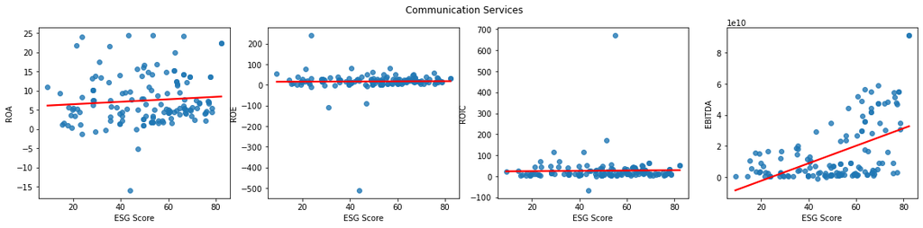

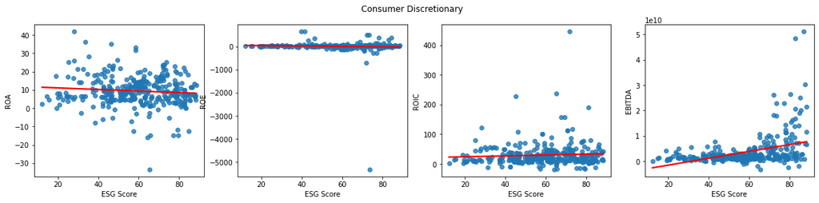

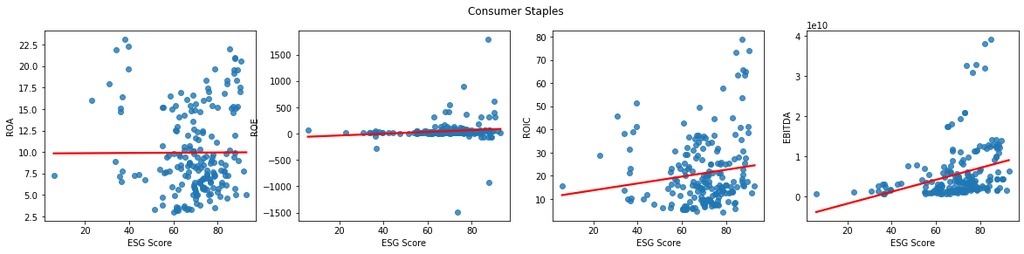

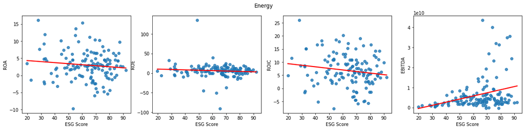

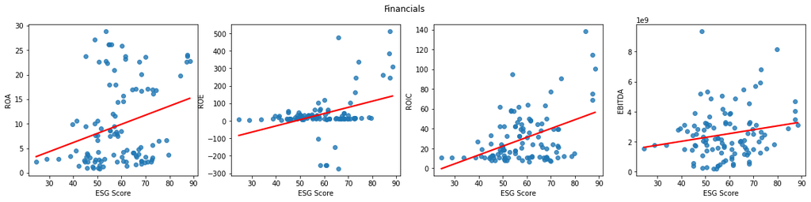

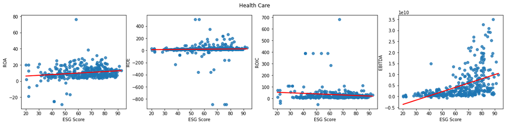

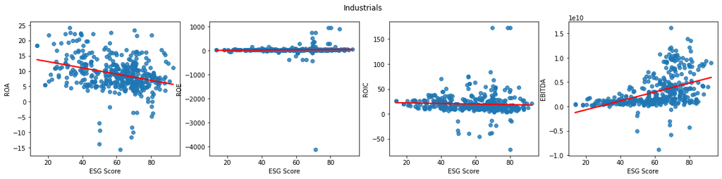

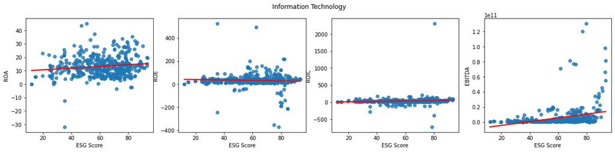

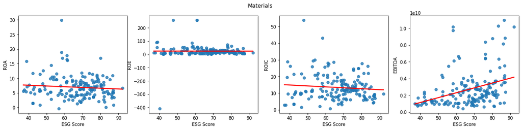

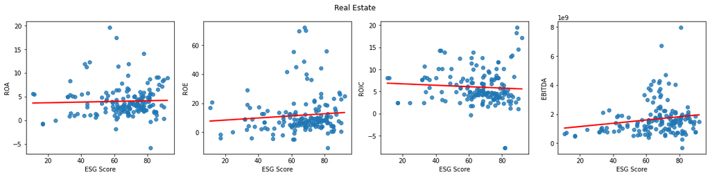

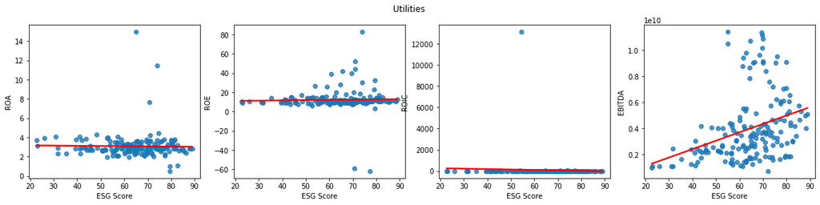

```python
for i in range(len(sector_df)):
    fig = plt.figure(figsize=(20,4))
    fig.suptitle(industries[i])
    ax = fig.add_subplot(1, 4, 1)
    sns.regplot(data=sector_df[i], x='ESG Score', y='ROA', ci=None,line_kws={"color": "red"},ax=ax)
    ax = fig.add_subplot(1, 4, 2)
    sns.regplot(data=sector_df[i], x='ESG Score', y='ROE', ci=None,line_kws={"color": "red"},ax=ax)
    ax = fig.add_subplot(1, 4, 3)
    sns.regplot(data=sector_df[i], x='ESG Score', y='ROIC', ci=None,line_kws={"color": "red"},ax=ax)
    ax = fig.add_subplot(1, 4, 4)
    sns.regplot(data=sector_df[i], x='ESG Score', y='EBITDA', ci=None,line_kws={"color": "red"},ax=ax)
    plt.show()
```

### Identifying how weakly or strongly correlated the variables are

```python
prof_vars = ['ROA', 'ROE','ROIC', 'EBITDA']
Industries=['Communication Services', 'Consumer Discretionary', 'Consumer Staples',
       'Energy', 'Financials', 'Health Care', 'Industrials',
       'Information Technology', 'Materials', 'Real Estate', 'Utilities']
for i in range(4):
    cc_ls = new_p[prof_vars[i]].to_list()
    print(prof_vars[i])
    print("=================================")
    for j in range(11):
        cc = cc_ls[j]
        #print(cc)
        cc = round(cc, 2)
        if (cc >= 0.8 and cc <= 1):
            print(Industries[j], ": Very Strong Positive (", cc,")")
        elif (cc >= 0.6 and cc <= 0.79):
            print(Industries[j], ": Strong Positive (", cc,")")
        elif (cc >= 0.4 and cc <= 0.59):
            print(Industries[j], ": Moderate Positive (", cc,")")
        elif (cc >= 0.2 and cc <= 0.39):
            print(Industries[j], ": Weak Positive (", cc,")")
        elif (cc >= 0 and cc < 0.19):
            print(Industries[j], ": Very Weak Positive (", cc,")")
        elif (cc >= -1 and cc <= -0.8):
            print(Industries[j], ": Very Strong Negative (", cc,")")
        elif (cc >= -0.79 and cc <= -0.6):
            print(Industries[j], ": Strong Negative (", cc,")")
        elif (cc >= -0.59 and cc <= -0.4):
            print(Industries[j], ": Moderate Negative (", cc,")")
        elif (cc >= -0.39 and cc <= -0.2):
            print(Industries[j], ": Weak Negative (", cc,")")
        elif (cc >= -0.19 and cc <= -0.01):
            print(Industries[j], ": Very Weak Negative (", cc,")")

    print()
```

```
ROA
=================================
Communication Services : Very Weak Positive ( 0.09 )
Consumer Discretionary : Very Weak Negative ( -0.09 )
Consumer Staples : Very Weak Positive ( 0.0 )
Energy : Very Weak Negative ( -0.11 )
Financials : Weak Positive ( 0.27 )
Health Care : Very Weak Positive ( 0.18 )
Industrials : Weak Negative ( -0.31 )
Information Technology : Very Weak Positive ( 0.14 )
Materials : Very Weak Negative ( -0.09 )
Real Estate : Very Weak Positive ( 0.04 )
Utilities : Very Weak Negative ( -0.02 )

ROE
=================================
Communication Services : Very Weak Positive ( 0.01 )
Consumer Discretionary : Very Weak Negative ( -0.05 )
Consumer Staples : Very Weak Positive ( 0.11 )
Energy : Very Weak Negative ( -0.09 )
Financials : Weak Positive ( 0.39 )
Health Care : Very Weak Positive ( 0.03 )
Industrials : Very Weak Positive ( 0.03 )
Information Technology : Very Weak Negative ( -0.05 )
Materials : Very Weak Positive ( -0.0 )
Real Estate : Very Weak Positive ( 0.09 )
Utilities : Very Weak Positive ( 0.03 )

ROIC
=================================
Communication Services : Very Weak Positive ( 0.02 )
Consumer Discretionary : Very Weak Positive ( 0.07 )
Consumer Staples : Very Weak Positive ( 0.14 )
Energy : Very Weak Negative ( -0.16 )
Financials : Moderate Positive ( 0.44 )
Health Care : Very Weak Negative ( -0.12 )
Industrials : Very Weak Negative ( -0.05 )
Information Technology : Very Weak Positive ( 0.08 )
Materials : Very Weak Negative ( -0.1 )
Real Estate : Very Weak Negative ( -0.07 )
Utilities : Very Weak Negative ( -0.05 )

EBITDA
=================================
Communication Services : Moderate Positive ( 0.53 )
Consumer Discretionary : Weak Positive ( 0.39 )
Consumer Staples : Weak Positive ( 0.31 )
Energy : Weak Positive ( 0.31 )
Health Care : Moderate Positive ( 0.48 )
Industrials : Moderate Positive ( 0.46 )
Information Technology : Weak Positive ( 0.31 )
Materials : Weak Positive ( 0.36 )
Real Estate : Very Weak Positive ( 0.17 )
Utilities : Weak Positive ( 0.34 )
```

# Finding Correlation for Equity Valuation Variables

### Merging the dataframe based on symbols

```python
pdList=[esg_scores,eps,dps,DY,per,EV,price_to_sales,pbv]
ev_var_ls=['ESG Score','EPS','DPS','DY','PER','EV','PTS','PBV']

del eps['Symbol']
del dps['Symbol']
del DY['Symbol']
del per['Symbol']
del EV['Symbol']
del price_to_sales['Symbol']
del pbv['Symbol']
ev_variables_df=pd.concat(pdList, axis=1)
for i in ev_var_ls:
    ev_variables_df=ev_variables_df[ev_variables_df[i] != 0]
```

```python
ev_variables_df
```

|  | Symbol | GICS Sector Name | ESG Score | EPS | DPS | DY | PER | EV | PTS | PBV |
| --- | --- | --- | --- | --- | --- | --- | --- | --- | --- | --- |
| 0 | MMM | Industrials | 89.862822 | 10.11618 | 5.920 | 3.332770 | 17.396337 | 1.140789e+11 | 2.875415 | 7.078823 |
| 1 | MMM | Industrials | 92.732718 | 9.35933 | 5.880 | 3.364037 | 20.285993 | 1.159227e+11 | 3.179323 | 8.486759 |
| 2 | MMM | Industrials | 88.540146 | 7.72005 | 5.760 | 3.264936 | 21.113857 | 1.133481e+11 | 3.174042 | 9.479577 |
| 3 | MMM | Industrials | 85.984531 | 8.88538 | 5.440 | 2.855044 | 20.975434 | 1.212466e+11 | 3.348389 | 10.826404 |
| 4 | MMM | Industrials | 87.233512 | 7.92884 | 4.700 | 1.996856 | 26.272814 | 1.484903e+11 | 4.522786 | 11.541930 |
| ... | ... | ... | ... | ... | ... | ... | ... | ... | ... | ... |
| 3013 | ZTS | Health Care | 65.292733 | 3.42270 | 0.800 | 0.604230 | 47.521011 | 8.270682e+10 | 12.023360 | 21.835833 |
| 3014 | ZTS | Health Care | 59.522098 | 3.11341 | 0.660 | 0.604458 | 43.347253 | 6.766221e+10 | 10.250115 | 23.561354 |
| 3015 | ZTS | Health Care | 58.928305 | 2.93285 | 0.542 | 0.766893 | 31.701089 | 4.614777e+10 | 7.183669 | 19.425430 |
| 3016 | ZTS | Health Care | 51.070515 | 1.75196 | 0.441 | 0.699611 | 37.997985 | 3.885525e+10 | 6.850946 | 17.668888 |
| 3017 | ZTS | Health Care | 45.265223 | 1.64785 | 0.390 | 0.699611 | 38.749140 | 3.026386e+10 | 5.411434 | 16.691930 |

2343 rows × 10 columns

```python
communication_services_df = ev_variables_df[ev_variables_df['GICS Sector Name'] == 'Communication Services']
communication_services_df
```

|  | Symbol | GICS Sector Name | ESG Score | EPS | DPS | DY | PER | EV | PTS | PBV |
| --- | --- | --- | --- | --- | --- | --- | --- | --- | --- | --- |
| 36 | ATVI.O | Communication Services | 67.716040 | 3.44260 | 0.410 | 0.706448 | 19.700101 | 4.542646e+10 | 5.724009 | 3.056719 |
| 37 | ATVI.O | Communication Services | 63.640830 | 2.82391 | 0.410 | 0.441572 | 32.538873 | 6.776179e+10 | 9.368119 | 4.989228 |
| 38 | ATVI.O | Communication Services | 59.539460 | 1.94942 | 0.370 | 0.622686 | 34.549525 | 4.323501e+10 | 6.631321 | 3.730451 |
| 39 | ATVI.O | Communication Services | 51.782054 | 2.39689 | 0.340 | 0.730084 | 29.549117 | 3.489727e+10 | 4.962334 | 3.333558 |
| 40 | ATVI.O | Communication Services | 43.986182 | 0.35640 | 0.300 | 0.473784 | 43.444552 | 4.868822e+10 | 6.850224 | 4.803202 |
| ... | ... | ... | ... | ... | ... | ... | ... | ... | ... | ... |
| 2821 | VZ | Communication Services | 77.093189 | 4.29768 | 2.480 | 4.272340 | 13.286595 | 3.511510e+11 | 1.893772 | 3.736235 |
| 2822 | VZ | Communication Services | 76.781866 | 4.65338 | 2.420 | 4.006515 | 15.779275 | 3.619072e+11 | 1.932933 | 4.309790 |
| 2823 | VZ | Communication Services | 71.846386 | 3.75799 | 2.373 | 4.286731 | 14.961240 | 3.442979e+11 | 1.779587 | 4.262811 |
| 2824 | VZ | Communication Services | 66.341752 | 7.36146 | 2.335 | 4.458719 | 13.582835 | 3.305378e+11 | 1.735465 | 8.042491 |
| 2825 | VZ | Communication Services | 56.722792 | 3.21268 | 2.270 | 4.458719 | 15.553885 | 3.192837e+11 | 1.701493 | 10.635910 |

72 rows × 10 columns

```python
consumer_discretionary_df = ev_variables_df[ev_variables_df['GICS Sector Name'] == 'Consumer Discretionary']
consumer_discretionary_df
```

|  | Symbol | GICS Sector Name | ESG Score | EPS | DPS | DY | PER | EV | PTS | PBV |
| --- | --- | --- | --- | --- | --- | --- | --- | --- | --- | --- |
| 60 | AAP | Consumer Discretionary | 66.278673 | 9.55073 | 3.25 | 1.667500 | 24.279721 | 1.538712e+10 | 1.363994 | 4.683706 |
| 61 | AAP | Consumer Discretionary | 57.843157 | 7.14492 | 1.00 | 0.634880 | 22.913945 | 1.065144e+10 | 1.084634 | 2.865197 |
| 62 | AAP | Consumer Discretionary | 43.227957 | 6.84179 | 0.24 | 0.149850 | 22.753588 | 1.126599e+10 | 1.143393 | 3.211366 |
| 63 | AAP | Consumer Discretionary | 62.966926 | 5.72836 | 0.24 | 0.152420 | 34.044743 | 1.155324e+10 | 1.206611 | 3.136335 |
| 64 | AAP | Consumer Discretionary | 54.873090 | 6.41621 | 0.24 | 0.240746 | 20.906866 | 8.047952e+09 | 0.782074 | 2.280217 |
| ... | ... | ... | ... | ... | ... | ... | ... | ... | ... | ... |
| 2989 | YUM | Consumer Discretionary | 78.144823 | 2.94463 | 1.88 | 1.731761 | 31.582193 | 4.279609e+10 | 5.844921 | -4.140058 |
| 2990 | YUM | Consumer Discretionary | 72.703976 | 4.13419 | 1.68 | 1.667825 | 27.995486 | 4.041701e+10 | 5.579018 | -3.769444 |
| 2991 | YUM | Consumer Discretionary | 82.363311 | 4.68693 | 1.44 | 1.566580 | 15.409013 | 3.828078e+10 | 5.030101 | -3.857731 |
| 2992 | YUM | Consumer Discretionary | 78.807757 | 3.77465 | 0.90 | 1.470408 | 46.068564 | 3.643905e+10 | 16.045539 | -4.519815 |
| 2993 | YUM | Consumer Discretionary | 64.074647 | 4.10750 | 1.73 | 1.470408 | 20.398500 | 2.959046e+10 | 3.744556 | -12.559114 |

222 rows × 10 columns

```python
consumer_staples_df = ev_variables_df[ev_variables_df['GICS Sector Name'] == 'Consumer Staples']
consumer_staples_df
```

|  | Symbol | GICS Sector Name | ESG Score | EPS | DPS | DY | PER | EV | PTS | PBV |
| --- | --- | --- | --- | --- | --- | --- | --- | --- | --- | --- |
| 42 | ADM | Consumer Staples | 83.618037 | 4.78622 | 1.48 | 2.189673 | 14.623255 | 4.590963e+10 | 0.471850 | 1.719824 |
| 43 | ADM | Consumer Staples | 83.947377 | 3.14742 | 1.44 | 2.856576 | 17.458613 | 3.533657e+10 | 0.447287 | 1.450572 |
| 44 | ADM | Consumer Staples | 80.860552 | 2.44071 | 1.40 | 3.020496 | 22.700892 | 3.380741e+10 | 0.401444 | 1.367930 |
| 45 | ADM | Consumer Staples | 76.270645 | 3.19224 | 1.34 | 3.270686 | 12.219164 | 2.996560e+10 | 0.356317 | 1.208364 |
| 46 | ADM | Consumer Staples | 78.708707 | 2.78846 | 1.28 | 3.193613 | 18.829720 | 2.903175e+10 | 0.365901 | 1.275169 |
| ... | ... | ... | ... | ... | ... | ... | ... | ... | ... | ... |
| 2881 | WMT | Consumer Staples | 81.944964 | 4.74535 | 2.16 | 1.498439 | 20.810806 | 4.503606e+11 | 0.743229 | 5.011466 |
| 2882 | WMT | Consumer Staples | 81.942940 | 5.18863 | 2.12 | 1.783911 | 22.944876 | 3.898589e+11 | 0.647052 | 4.708883 |
| 2883 | WMT | Consumer Staples | 73.651127 | 2.26486 | 2.09 | 2.232958 | 56.463100 | 3.261800e+11 | 0.528689 | 3.767609 |
| 2884 | WMT | Consumer Staples | 76.554479 | 3.27641 | 2.04 | 2.065823 | 26.257921 | 3.337742e+11 | 0.590966 | 3.849104 |
| 2885 | WMT | Consumer Staples | 78.117771 | 4.38400 | 2.00 | 2.065823 | 15.008990 | 2.561249e+11 | 0.438335 | 2.739249 |

191 rows × 10 columns

```python
energy_df = ev_variables_df[ev_variables_df['GICS Sector Name'] == 'Energy']
energy_df
```

|  | Symbol | GICS Sector Name | ESG Score | EPS | DPS | DY | PER | EV | PTS | PBV |
| --- | --- | --- | --- | --- | --- | --- | --- | --- | --- | --- |
| 264 | APA.O | Energy | 65.477919 | 2.59467 | 0.24 | 1.859427 | 16.956420 | 1.960644e+10 | 1.414692 | -9.283113 |
| 265 | APA.O | Energy | 62.979780 | -12.85714 | 0.10 | 0.704722 | 16.956420 | 1.695942e+10 | 1.083198 | -3.263961 |
| 266 | APA.O | Energy | 57.819646 | -9.42440 | 1.00 | 3.907776 | 16.956420 | 2.120477e+10 | 1.410549 | 1.527124 |
| 267 | APA.O | Energy | 58.818313 | 0.10417 | 1.00 | 3.809524 | 10.173945 | 2.013402e+10 | 1.367607 | 1.315839 |
| 268 | APA.O | Energy | 48.621164 | 3.40470 | 1.00 | 2.368546 | 24.349872 | 2.531340e+10 | 2.820659 | 2.293995 |
| ... | ... | ... | ... | ... | ... | ... | ... | ... | ... | ... |
| 2953 | WMB | Energy | 72.108091 | 0.17117 | 1.60 | 7.980050 | 105.793584 | 4.951339e+10 | 3.146159 | 2.015802 |
| 2954 | WMB | Energy | 75.266542 | 0.69769 | 1.52 | 6.408094 | 189.790366 | 5.403280e+10 | 3.464666 | 2.110612 |
| 2955 | WMB | Energy | 63.950113 | -0.16023 | 1.36 | 6.167800 | 125.234282 | 5.029945e+10 | 3.064575 | 1.709193 |
| 2956 | WMB | Energy | 51.111792 | 2.62396 | 1.20 | 3.935717 | 53.671073 | 5.187750e+10 | 3.150544 | 3.105776 |
| 2957 | WMB | Energy | 55.046553 | -0.56483 | 1.68 | 3.935717 | 53.671073 | 5.738708e+10 | 3.199819 | 4.805556 |

130 rows × 10 columns

```python
financials_df= ev_variables_df[ev_variables_df['GICS Sector Name'] == 'Financials']
financials_df
```

|  | Symbol | GICS Sector Name | ESG Score | EPS | DPS | DY | PER | EV | PTS | PBV |
| --- | --- | --- | --- | --- | --- | --- | --- | --- | --- | --- |
| 72 | AFL | Financials | 55.068524 | 6.39104 | 1.32 | 2.740195 | 9.470041 | 4.036863e+10 | 1.710430 | 1.153490 |
| 73 | AFL | Financials | 55.068524 | 6.67140 | 1.12 | 2.968293 | 6.952392 | 3.336074e+10 | 1.429841 | 0.963328 |
| 74 | AFL | Financials | 59.551232 | 4.42640 | 1.08 | 2.041588 | 13.033184 | 4.072155e+10 | 1.771745 | 1.321026 |
| 75 | AFL | Financials | 54.844457 | 3.76944 | 1.08 | 2.282704 | 11.634677 | 3.653389e+10 | 1.570757 | 1.496403 |
| 76 | AFL | Financials | 60.258481 | 5.77044 | 0.87 | 2.050581 | 12.745827 | 3.483167e+10 | 1.551809 | 1.573206 |
| ... | ... | ... | ... | ... | ... | ... | ... | ... | ... | ... |
| 3007 | ZION.O | Financials | 54.258814 | 3.02512 | 1.36 | 3.130755 | 18.545399 | 9.713664e+09 | 2.913973 | 0.929128 |
| 3008 | ZION.O | Financials | 45.462987 | 4.16077 | 1.28 | 2.619414 | 12.144916 | 1.444148e+10 | 3.287698 | 1.178022 |
| 3009 | ZION.O | Financials | 38.087569 | 4.08230 | 1.04 | 2.945508 | 10.810122 | 1.253762e+10 | 3.278736 | 1.036537 |
| 3010 | ZION.O | Financials | 35.879043 | 2.59953 | 0.44 | 1.259099 | 19.023702 | 1.518498e+10 | 4.762707 | 1.307997 |
| 3011 | ZION.O | Financials | 35.764204 | 1.99252 | 0.28 | 1.259099 | 23.629785 | 1.061042e+10 | 4.552200 | 1.142513 |

382 rows × 10 columns

```python
health_care_df= ev_variables_df[ev_variables_df['GICS Sector Name'] == 'Health Care']
health_care_df
```

|  | Symbol | GICS Sector Name | ESG Score | EPS | DPS | DY | PER | EV | PTS | PBV |
| --- | --- | --- | --- | --- | --- | --- | --- | --- | --- | --- |
| 12 | ABT | Health Care | 82.203654 | 3.95249 | 1.800 | 1.335797 | 34.685699 | 2.577897e+11 | 5.882308 | 7.229932 |
| 13 | ABT | Health Care | 82.965995 | 2.51680 | 1.440 | 1.643986 | 58.247107 | 2.080969e+11 | 6.022652 | 6.182880 |
| 14 | ABT | Health Care | 80.952100 | 2.07019 | 1.280 | 1.657840 | 46.956428 | 1.685721e+11 | 4.898997 | 4.827861 |
| 15 | ABT | Health Care | 77.683987 | 1.33785 | 1.120 | 1.769667 | 54.793379 | 1.432366e+11 | 4.178527 | 4.137293 |
| 16 | ABT | Health Care | 81.993237 | 0.27273 | 1.060 | 1.962502 | 47.052519 | 1.123481e+11 | 3.952259 | 3.101151 |
| ... | ... | ... | ... | ... | ... | ... | ... | ... | ... | ... |
| 3013 | ZTS | Health Care | 65.292733 | 3.42270 | 0.800 | 0.604230 | 47.521011 | 8.270682e+10 | 12.023360 | 21.835833 |
| 3014 | ZTS | Health Care | 59.522098 | 3.11341 | 0.660 | 0.604458 | 43.347253 | 6.766221e+10 | 10.250115 | 23.561354 |
| 3015 | ZTS | Health Care | 58.928305 | 2.93285 | 0.542 | 0.766893 | 31.701089 | 4.614777e+10 | 7.183669 | 19.425430 |
| 3016 | ZTS | Health Care | 51.070515 | 1.75196 | 0.441 | 0.699611 | 37.997985 | 3.885525e+10 | 6.850946 | 17.668888 |
| 3017 | ZTS | Health Care | 45.265223 | 1.64785 | 0.390 | 0.699611 | 38.749140 | 3.026386e+10 | 5.411434 | 16.691930 |

218 rows × 10 columns

```python
industrials_df= ev_variables_df[ev_variables_df['GICS Sector Name'] == 'Industrials']
industrials_df
```

|  | Symbol | GICS Sector Name | ESG Score | EPS | DPS | DY | PER | EV | PTS | PBV |
| --- | --- | --- | --- | --- | --- | --- | --- | --- | --- | --- |
| 0 | MMM | Industrials | 89.862822 | 10.11618 | 5.92 | 3.332770 | 17.396337 | 1.140789e+11 | 2.875415 | 7.078823 |
| 1 | MMM | Industrials | 92.732718 | 9.35933 | 5.88 | 3.364037 | 20.285993 | 1.159227e+11 | 3.179323 | 8.486759 |
| 2 | MMM | Industrials | 88.540146 | 7.72005 | 5.76 | 3.264936 | 21.113857 | 1.133481e+11 | 3.174042 | 9.479577 |
| 3 | MMM | Industrials | 85.984531 | 8.88538 | 5.44 | 2.855044 | 20.975434 | 1.212466e+11 | 3.348389 | 10.826404 |
| 4 | MMM | Industrials | 87.233512 | 7.92884 | 4.70 | 1.996856 | 26.272814 | 1.484903e+11 | 4.522786 | 11.541930 |
| ... | ... | ... | ... | ... | ... | ... | ... | ... | ... | ... |
| 2983 | XYL | Industrials | 82.684210 | 1.40254 | 1.04 | 1.021711 | 82.291785 | 1.984481e+10 | 3.764016 | 6.394272 |
| 2984 | XYL | Industrials | 76.885450 | 2.21307 | 0.96 | 1.218429 | 27.665028 | 1.608041e+10 | 2.695367 | 4.916867 |
| 2985 | XYL | Industrials | 73.763471 | 3.03147 | 0.84 | 1.258993 | 27.419216 | 1.413165e+10 | 2.352031 | 4.578874 |
| 2986 | XYL | Industrials | 77.157672 | 1.82974 | 0.72 | 1.055718 | 39.758418 | 1.426872e+10 | 2.706899 | 4.973090 |
| 2987 | XYL | Industrials | 70.321177 | 1.44444 | 0.62 | 1.055718 | 27.485458 | 9.424072e+09 | 2.417731 | 3.989173 |

366 rows × 10 columns

```python
information_technology_df= ev_variables_df[ev_variables_df['GICS Sector Name'] == 'Information Technology']
information_technology_df
```

|  | Symbol | GICS Sector Name | ESG Score | EPS | DPS | DY | PER | EV | PTS | PBV |
| --- | --- | --- | --- | --- | --- | --- | --- | --- | --- | --- |
| 30 | ACN | Information Technology | 80.688107 | 10.70955 | 3.88 | 0.935955 | 43.121652 | 2.679182e+11 | 5.078719 | 12.884543 |
| 31 | ACN | Information Technology | 78.264807 | 9.15508 | 3.52 | 1.347575 | 32.016640 | 1.646065e+11 | 3.860811 | 9.250582 |
| 32 | ACN | Information Technology | 77.511350 | 7.89470 | 3.20 | 1.519685 | 28.097279 | 1.329730e+11 | 3.146193 | 8.824082 |
| 33 | ACN | Information Technology | 77.801686 | 7.36046 | 2.92 | 2.070775 | 20.790269 | 8.592106e+10 | 2.154843 | 7.095911 |
| 34 | ACN | Information Technology | 82.172466 | 6.34060 | 2.66 | 1.737540 | 27.130292 | 9.551585e+10 | 2.613464 | 10.684839 |
| ... | ... | ... | ... | ... | ... | ... | ... | ... | ... | ... |
| 2855 | V | Information Technology | 70.543274 | 2.79708 | 0.69 | 0.684091 | 31.535719 | 1.942058e+11 | 12.037183 | 5.539026 |
| 2930 | WDC.O | Information Technology | 52.802500 | -0.83893 | 1.50 | 3.151095 | 13.713091 | 2.584027e+10 | 1.211493 | 1.977217 |
| 2931 | WDC.O | Information Technology | 43.621885 | -2.58219 | 2.00 | 5.409792 | 5.870164 | 1.719703e+10 | 0.522106 | 0.939282 |
| 2932 | WDC.O | Information Technology | 41.421455 | 2.19870 | 2.00 | 2.514774 | 16.600949 | 2.973391e+10 | 1.202654 | 1.945547 |
| 2933 | WDC.O | Information Technology | 37.859961 | 1.34122 | 2.00 | 2.514774 | 16.600949 | 2.820595e+10 | 1.351962 | 1.797285 |

257 rows × 10 columns

```python
materials_df= ev_variables_df[ev_variables_df['GICS Sector Name'] == 'Materials']
materials_df
```

|  | Symbol | GICS Sector Name | ESG Score | EPS | DPS | DY | PER | EV | PTS | PBV |
| --- | --- | --- | --- | --- | --- | --- | --- | --- | --- | --- |
| 84 | APD | Materials | 81.631560 | 10.13978 | 6.36 | 1.971998 | 33.371905 | 6.984443e+10 | 6.534896 | 4.975160 |
| 85 | APD | Materials | 81.631560 | 9.43416 | 5.84 | 1.961789 | 31.949726 | 6.237047e+10 | 6.826471 | 4.998956 |
| 86 | APD | Materials | 80.268096 | 8.48718 | 5.18 | 1.974552 | 29.809944 | 5.310324e+10 | 5.814309 | 4.685838 |
| 87 | APD | Materials | 85.139446 | 7.94224 | 4.58 | 2.749141 | 20.883405 | 3.630737e+10 | 3.936303 | 3.235866 |
| 88 | APD | Materials | 78.934903 | 6.78351 | 4.25 | 2.315943 | 31.784775 | 3.628802e+10 | 4.385110 | 3.552004 |
| ... | ... | ... | ... | ... | ... | ... | ... | ... | ... | ... |
| 2935 | WRK | Materials | 71.313374 | -2.66590 | 0.88 | 1.837813 | 14.181223 | 2.064999e+10 | 0.651483 | 1.066281 |
| 2936 | WRK | Materials | 64.462161 | 3.32999 | 1.33 | 4.334654 | 12.782322 | 2.100858e+10 | 0.605861 | 0.947926 |
| 2937 | WRK | Materials | 60.138822 | 7.33603 | 1.82 | 4.819915 | 14.231442 | 1.536972e+10 | 0.587907 | 0.834582 |
| 2938 | WRK | Materials | 56.351678 | 2.76926 | 1.72 | 2.721088 | 22.842089 | 2.240772e+10 | 1.083650 | 1.555421 |
| 2939 | WRK | Materials | 52.466261 | -1.56024 | 1.63 | 2.721088 | 88.847278 | 1.828215e+10 | 0.897483 | 1.309850 |

165 rows × 10 columns

```python
real_estate_df= ev_variables_df[ev_variables_df['GICS Sector Name'] == 'Real Estate']
real_estate_df
```

|  | Symbol | GICS Sector Name | ESG Score | EPS | DPS | DY | PER | EV | PTS | PBV |
| --- | --- | --- | --- | --- | --- | --- | --- | --- | --- | --- |
| 108 | ARE | Real Estate | 74.322885 | 3.82069 | 4.48 | 2.063150 | 34.020114 | 4.573745e+10 | 17.267249 | 2.321484 |
| 109 | ARE | Real Estate | 73.782880 | 6.01463 | 4.24 | 2.446415 | 41.031332 | 3.305988e+10 | 13.141665 | 2.219878 |
| 110 | ARE | Real Estate | 75.752945 | 3.11929 | 4.00 | 2.549821 | 151.185965 | 2.616391e+10 | 12.712136 | 2.323032 |
| 111 | ARE | Real Estate | 72.902807 | 3.52284 | 3.73 | 3.366886 | 27.775903 | 1.848618e+10 | 9.637184 | 1.774011 |
| 112 | ARE | Real Estate | 69.202140 | 1.57929 | 3.45 | 2.756720 | 148.698504 | 1.777050e+10 | 11.590322 | 2.277549 |
| ... | ... | ... | ... | ... | ... | ... | ... | ... | ... | ... |
| 2941 | WY | Real Estate | 77.613142 | 1.06565 | 0.51 | 2.028035 | 48.619209 | 3.021456e+10 | 3.395233 | 2.793896 |
| 2942 | WY | Real Estate | 68.308558 | -0.10189 | 1.36 | 4.503311 | 48.619209 | 2.897630e+10 | 3.225149 | 2.490916 |
| 2943 | WY | Real Estate | 72.246953 | 0.98834 | 1.32 | 6.221409 | 13.569302 | 2.246151e+10 | 2.034471 | 1.721334 |
| 2944 | WY | Real Estate | 81.061767 | 0.76916 | 1.25 | 3.630176 | 67.967061 | 3.262429e+10 | 3.635491 | 2.794475 |
| 2945 | WY | Real Estate | 76.574265 | 1.39119 | 1.24 | 3.630176 | 47.848261 | 3.057608e+10 | 3.550445 | 2.331157 |

172 rows × 10 columns

```python
utilities_df= ev_variables_df[ev_variables_df['GICS Sector Name'] == 'Utilities']
utilities_df
```

|  | Symbol | GICS Sector Name | ESG Score | EPS | DPS | DY | PER | EV | PTS | PBV |
| --- | --- | --- | --- | --- | --- | --- | --- | --- | --- | --- |
| 66 | AES | Utilities | 71.111716 | -0.61411 | 0.572 | 2.600823 | 31.705853 | 3.889209e+10 | 1.482306 | 4.652828 |
| 67 | AES | Utilities | 71.111716 | 0.06886 | 0.572 | 2.561702 | 31.705853 | 3.802358e+10 | 1.639973 | 7.799692 |
| 68 | AES | Utilities | 69.619695 | 0.45427 | 0.550 | 2.880402 | 25.536065 | 3.462666e+10 | 1.272896 | 4.207473 |
| 69 | AES | Utilities | 65.723051 | 1.80902 | 0.530 | 3.775934 | 37.491249 | 3.066782e+10 | 0.890287 | 2.897677 |
| 70 | AES | Utilities | 60.703987 | -1.75909 | 0.490 | 4.801477 | 37.491249 | 3.118399e+10 | 0.880136 | 2.244817 |
| ... | ... | ... | ... | ... | ... | ... | ... | ... | ... | ... |
| 2977 | XEL.O | Utilities | 81.804921 | 2.78977 | 1.720 | 2.579871 | 23.797626 | 5.500858e+10 | 3.079219 | 2.542784 |
| 2978 | XEL.O | Utilities | 88.273393 | 2.63846 | 1.640 | 2.551583 | 25.418470 | 5.186875e+10 | 2.932171 | 2.533532 |
| 2979 | XEL.O | Utilities | 77.489031 | 2.46771 | 1.520 | 3.085042 | 19.982317 | 4.160564e+10 | 2.210734 | 2.078935 |
| 2980 | XEL.O | Utilities | 72.491851 | 2.25540 | 1.440 | 2.993141 | 20.661104 | 3.965332e+10 | 2.142350 | 2.135472 |
| 2981 | XEL.O | Utilities | 73.655286 | 2.20629 | 1.360 | 2.993141 | 18.760342 | 3.479875e+10 | 1.886613 | 1.881488 |

168 rows × 10 columns

### Getting correlation and p-value

```python
industries=['Communication Services', 'Consumer Discretionary', 'Consumer Staples',
       'Energy', 'Financials', 'Health Care', 'Industrials',
       'Information Technology', 'Materials', 'Real Estate', 'Utilities']
ev_var_ls=['EPS','DPS','DY','PER','EV','PTS','PBV']
ev_var_corr_ls=['EPS_corr','DPS_corr','DY_corr','PER_corr','EV_corr','PTS_corr','PBV_corr']
ev_var_p_ls=['EPS_p','DPS_p','DY_p','PER_p','EV_p','PTS_p','PBV_p']
sector_df=[communication_services_df, consumer_discretionary_df, consumer_staples_df,energy_df, financials_df,
          health_care_df,industrials_df,information_technology_df,materials_df,real_estate_df,utilities_df]

ev_var_corr_df = pd.DataFrame()
ev_var_corr_df['GICS Sector Names']=industries
ev_var_corr_df=ev_var_corr_df.set_index('GICS Sector Names')
ev_var_corr_df[['EPS_corr','DPS_corr','DY_corr','PER_corr','EV_corr','PTS_corr','PBV_corr']]=None
ev_var_corr_df[['EPS_p','DPS_p','DY_p','PER_p','EV_p','PTS_p','PBV_p']]=None
for j in range(11):
    for i in range(7):
        ev_var_corr_df.loc[industries[j]][ev_var_corr_ls[i]]=sector_df[j]['ESG Score'].corr(sector_df[j][ev_var_ls[i]])
        ev_var_corr_df.loc[industries[j]][ev_var_p_ls[i]]=(stats.pearsonr(sector_df[j]['ESG Score'],sector_df[j][ev_var_ls[i]]))[1]
ev_var_corr_df
```

| GICS Sector Names | EPS_corr | DPS_corr | DY_corr | PER_corr | EV_corr | PTS_corr | PBV_corr | EPS_p | DPS_p | DY_p | PER_p | EV_p | PTS_p | PBV_p |
| --- | --- | --- | --- | --- | --- | --- | --- | --- | --- | --- | --- | --- | --- | --- |
| Communication Services | 0.279305 | 0.513785 | 0.236543 | -0.282168 | 0.557435 | -0.019285 | 0.018185 | 0.017501 | 0.000004 | 0.045447 | 0.016333 | 0.0 | 0.87226 | 0.879487 |
| Consumer Discretionary | 0.055678 | 0.294762 | 0.308474 | -0.109764 | 0.390321 | 0.1476 | 0.018559 | 0.409061 | 0.000008 | 0.000003 | 0.10286 | 0.0 | 0.02789 | 0.783327 |
| Consumer Staples | -0.071575 | 0.259768 | 0.442298 | -0.003753 | 0.27063 | -0.140502 | -0.116242 | 0.325134 | 0.000285 | 0.0 | 0.958901 | 0.000153 | 0.052543 | 0.10929 |
| Energy | -0.109348 | 0.151373 | 0.149667 | -0.429954 | 0.320755 | -0.431655 | -0.14391 | 0.215555 | 0.085583 | 0.089212 | 0.0 | 0.000199 | 0.0 | 0.102366 |
| Financials | 0.174992 | 0.145563 | 0.289715 | -0.181441 | 0.381695 | 0.048745 | 0.121769 | 0.000591 | 0.00436 | 0.0 | 0.000365 | 0.0 | 0.342036 | 0.017265 |
| Health Care | 0.119973 | 0.369324 | 0.333627 | -0.138886 | 0.416949 | 0.008823 | 0.057768 | 0.077131 | 0.0 | 0.0 | 0.040484 | 0.0 | 0.896947 | 0.396023 |
| Industrials | 0.176261 | 0.352953 | 0.278675 | -0.042042 | 0.457266 | -0.273173 | -0.01968 | 0.000706 | 0.0 | 0.0 | 0.422605 | 0.0 | 0.0 | 0.707474 |
| Information Technology | 0.039424 | 0.08363 | 0.161986 | -0.113109 | 0.272076 | -0.034919 | -0.078024 | 0.529234 | 0.181386 | 0.009285 | 0.070258 | 0.00001 | 0.577372 | 0.212534 |
| Materials | -0.054463 | 0.22013 | 0.172029 | -0.003793 | 0.287676 | 0.154575 | -0.016519 | 0.48719 | 0.004496 | 0.027143 | 0.961438 | 0.000179 | 0.047436 | 0.833202 |
| Real Estate | -0.032835 | -0.055213 | 0.228 | -0.040261 | 0.150036 | -0.163913 | 0.022089 | 0.668936 | 0.471907 | 0.002629 | 0.600014 | 0.049474 | 0.031668 | 0.773641 |
| Utilities | 0.104014 | 0.215195 | -0.112451 | -0.022657 | 0.407164 | 0.098257 | 0.041829 | 0.179677 | 0.00509 | 0.14671 | 0.770657 | 0.0 | 0.205115 | 0.590335 |

```python
ev_var_p_df = ev_var_corr_df[['EPS_p','DPS_p','DY_p','PER_p','EV_p','PTS_p','PBV_p']]
ev_var_p_df
```

| GICS Sector Names | EPS_p | DPS_p | DY_p | PER_p | EV_p | PTS_p | PBV_p |
| --- | --- | --- | --- | --- | --- | --- | --- |
| Communication Services | 0.017501 | 0.000004 | 0.045447 | 0.016333 | 0.0 | 0.87226 | 0.879487 |
| Consumer Discretionary | 0.409061 | 0.000008 | 0.000003 | 0.10286 | 0.0 | 0.02789 | 0.783327 |
| Consumer Staples | 0.325134 | 0.000285 | 0.0 | 0.958901 | 0.000153 | 0.052543 | 0.10929 |
| Energy | 0.215555 | 0.085583 | 0.089212 | 0.0 | 0.000199 | 0.0 | 0.102366 |
| Financials | 0.000591 | 0.00436 | 0.0 | 0.000365 | 0.0 | 0.342036 | 0.017265 |
| Health Care | 0.077131 | 0.0 | 0.0 | 0.040484 | 0.0 | 0.896947 | 0.396023 |
| Industrials | 0.000706 | 0.0 | 0.0 | 0.422605 | 0.0 | 0.0 | 0.707474 |
| Information Technology | 0.529234 | 0.181386 | 0.009285 | 0.070258 | 0.00001 | 0.577372 | 0.212534 |
| Materials | 0.48719 | 0.004496 | 0.027143 | 0.961438 | 0.000179 | 0.047436 | 0.833202 |
| Real Estate | 0.668936 | 0.471907 | 0.002629 | 0.600014 | 0.049474 | 0.031668 | 0.773641 |
| Utilities | 0.179677 | 0.00509 | 0.14671 | 0.770657 | 0.0 | 0.205115 | 0.590335 |

### Printing correlation table

```python
new_ev=ev_var_corr_df[['EPS_corr','DPS_corr','DY_corr','PER_corr','EV_corr','PTS_corr','PBV_corr']].copy()
new_ev=new_ev.rename(columns={'EPS_corr': 'EPS','DPS_corr':'DPS','DY_corr':'DY','PER_corr':'PER',
                              'EV_corr':'EV','PTS_corr':'PTS','PBV_corr':'PBV'})
new_ev
```

| GICS Sector Names | EPS | DPS | DY | PER | EV | PTS | PBV |
| --- | --- | --- | --- | --- | --- | --- | --- |
| Communication Services | 0.279305 | 0.513785 | 0.236543 | -0.282168 | 0.557435 | -0.019285 | 0.018185 |
| Consumer Discretionary | 0.055678 | 0.294762 | 0.308474 | -0.109764 | 0.390321 | 0.1476 | 0.018559 |
| Consumer Staples | -0.071575 | 0.259768 | 0.442298 | -0.003753 | 0.27063 | -0.140502 | -0.116242 |
| Energy | -0.109348 | 0.151373 | 0.149667 | -0.429954 | 0.320755 | -0.431655 | -0.14391 |
| Financials | 0.174992 | 0.145563 | 0.289715 | -0.181441 | 0.381695 | 0.048745 | 0.121769 |
| Health Care | 0.119973 | 0.369324 | 0.333627 | -0.138886 | 0.416949 | 0.008823 | 0.057768 |
| Industrials | 0.176261 | 0.352953 | 0.278675 | -0.042042 | 0.457266 | -0.273173 | -0.01968 |
| Information Technology | 0.039424 | 0.08363 | 0.161986 | -0.113109 | 0.272076 | -0.034919 | -0.078024 |
| Materials | -0.054463 | 0.22013 | 0.172029 | -0.003793 | 0.287676 | 0.154575 | -0.016519 |
| Real Estate | -0.032835 | -0.055213 | 0.228 | -0.040261 | 0.150036 | -0.163913 | 0.022089 |
| Utilities | 0.104014 | 0.215195 | -0.112451 | -0.022657 | 0.407164 | 0.098257 | 0.041829 |

#### Correlation Analysis

In the above table, negative numbers shows increase in Environment, Social and Governance scores decreases the scores of other variables, whereas positive correlation shows increase in ESG scores increase the other ratios.

#### Dividend per share (DPS):

It showed positive correlation of ESG scores for all of the sectors. All the sectors DPS increased with increase in ESG scores, except sector 'Real Estate' which showed negative correlation.

#### Dividend yield (DY) :

There is positive trend between ESG scores and all the sectors for Dividend Yield, except 'Utilities'.

#### Price to earnings ratio (PER):

Overall, there is decrease in Price to Earnings ratios (PER) for all sectors as ESG score increases.

#### Enterprise value (EV):

Overall, there is increase in Enterprise Value ratios for all sectors with increase in ESG score.

#### Price to sales per share ratio (PTS):

Overall, there is decrease in Price to sales per share ratio for sectors 'Communication Services', 'Consumer Staples', 'Energy','Industrials', 'Information Technology', 'Real Estate' as ESG score increases. However, there is increase in PTS ratio for the rest of the sectors.

#### Price to book value (P/BV):

Overall, there is decrease in Price to Book ratios for sectors 'Consumer Staples','Energy', 'Industrials','Information Technology', 'Materials' with increase in ESG scores whereas the rest of the sectors shows increasing trend with increase in ESG scores.

### Graphs for ESG Scores vs. Equity Valuation Variables grouped by sectors

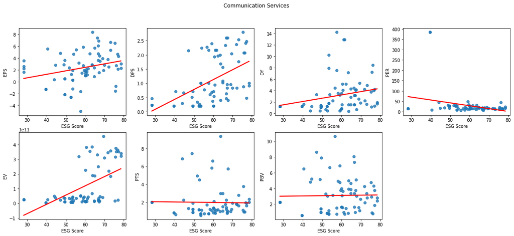

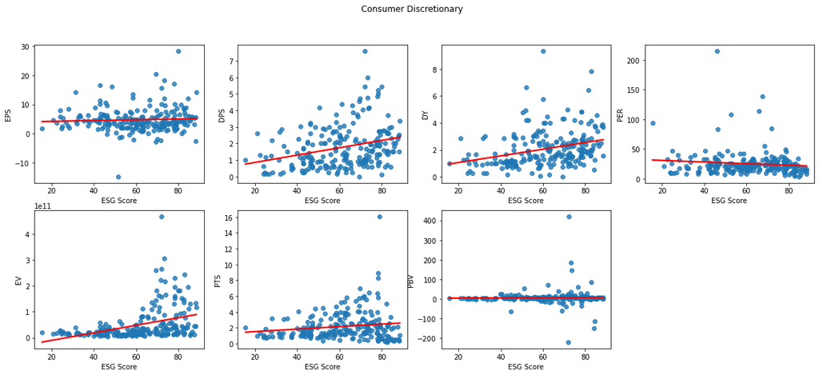

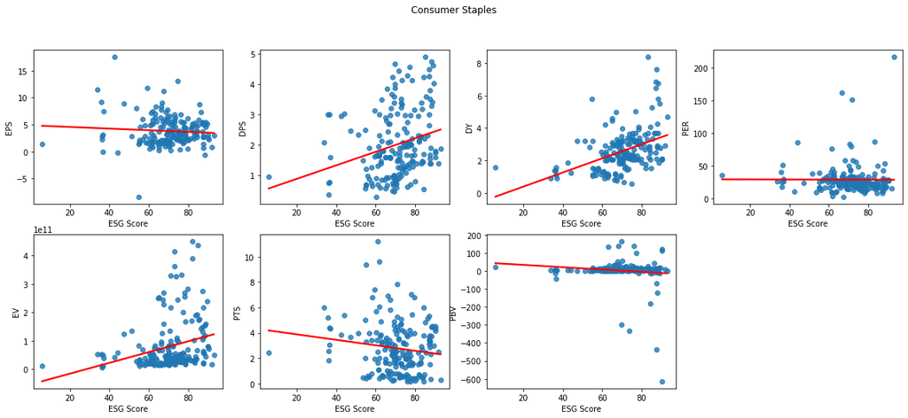

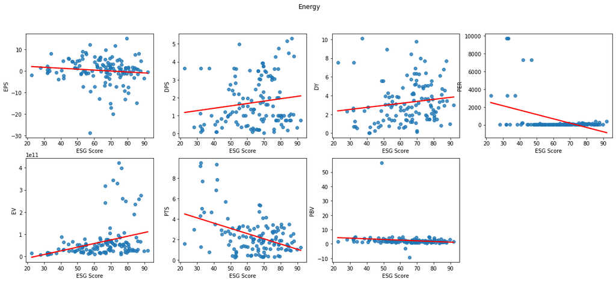

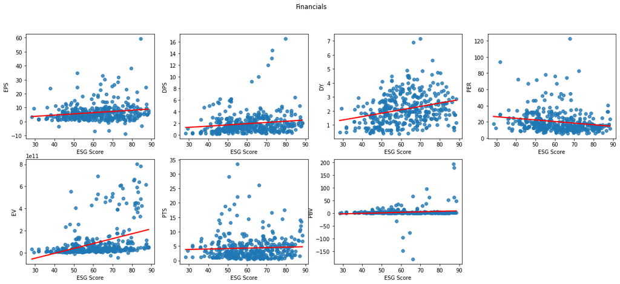

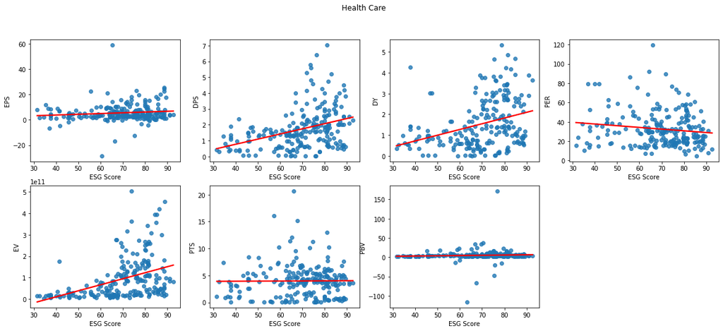

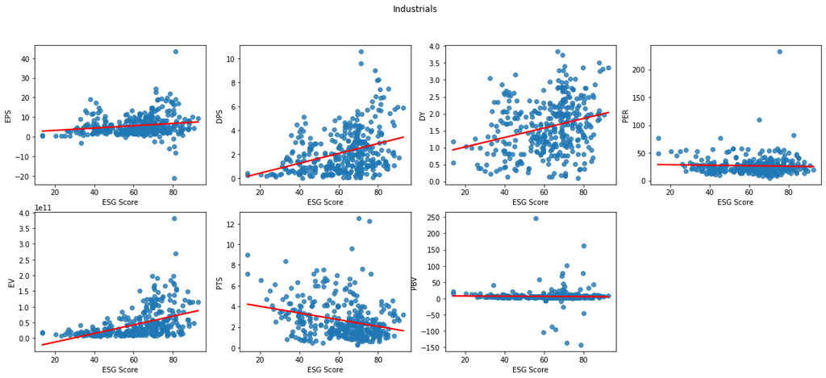

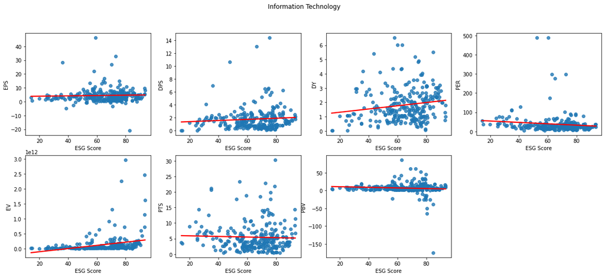

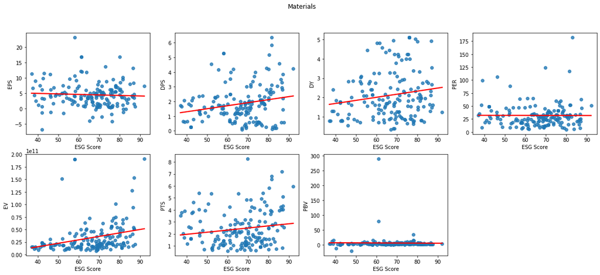

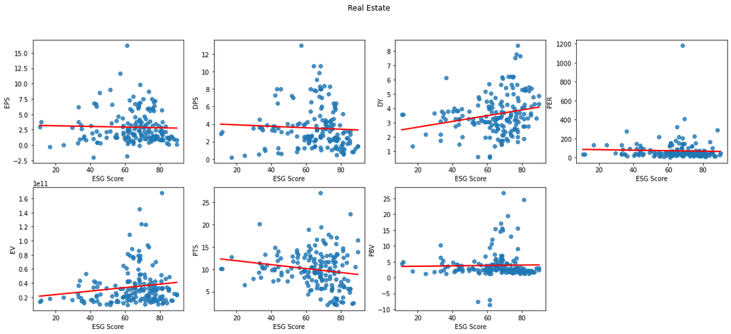

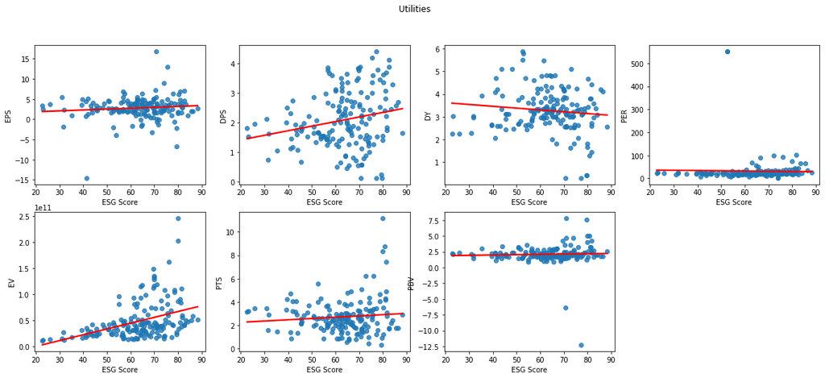

```python
for i in range(len(sector_df)):
    fig = plt.figure(figsize=(20,8))
    fig.suptitle(industries[i])
    ax = fig.add_subplot(2, 4, 1)
    sns.regplot(data=sector_df[i], x='ESG Score', y='EPS', ci=None, line_kws={"color": "red"}, ax=ax)
    ax = fig.add_subplot(2, 4, 2)
    sns.regplot(data=sector_df[i], x='ESG Score', y='DPS', ci=None,line_kws={"color": "red"},ax=ax)
    ax = fig.add_subplot(2, 4, 3)
    sns.regplot(data=sector_df[i], x='ESG Score', y='DY', ci=None,line_kws={"color": "red"},ax=ax)
    ax = fig.add_subplot(2, 4, 4)
    sns.regplot(data=sector_df[i], x='ESG Score', y='PER', ci=None,line_kws={"color": "red"},ax=ax)
    ax = fig.add_subplot(2, 4, 5)
    sns.regplot(data=sector_df[i], x='ESG Score', y='EV', ci=None,line_kws={"color": "red"},ax=ax)
    ax = fig.add_subplot(2, 4, 6)
    sns.regplot(data=sector_df[i], x='ESG Score', y='PTS', ci=None,line_kws={"color": "red"},ax=ax)
    ax = fig.add_subplot(2, 4, 7)
    sns.regplot(data=sector_df[i], x='ESG Score', y='PBV', ci=None,line_kws={"color": "red"},ax=ax)
    plt.show()
```

### Identifying how weakly or strongly correlated the variables are

```python
ev_vars = ['EPS', 'DPS','DY', 'PER', 'EV', 'PTS', 'PBV']
Industries=['Communication Services', 'Consumer Discretionary', 'Consumer Staples',
       'Energy', 'Financials', 'Health Care', 'Industrials',
       'Information Technology', 'Materials', 'Real Estate', 'Utilities']
for i in range(7):
    cc_ls = new_ev[ev_vars[i]].to_list()
    print(ev_vars[i])
    print("=================================")
    for j in range(11):
        cc = cc_ls[j]
        cc = round(cc,2)
        #print(cc)
        if (cc >= 0.8 and cc <= 1):
            print(Industries[j], ": Very Strong Positive (", cc,")")
        elif (cc >= 0.6 and cc <= 0.79):
            print(Industries[j], ": Strong Positive (", cc,")")
        elif (cc >= 0.4 and cc <= 0.59):
            print(Industries[j], ": Moderate Positive (", cc,")")
        elif (cc >= 0.2 and cc <= 0.39):
            print(Industries[j], ": Weak Positive (", cc,")")
        elif (cc >= 0 and cc < 0.19):
            print(Industries[j], ": Very Weak Positive (", cc,")")
        elif (cc >= -1 and cc <= -0.8):
            print(Industries[j], ": Very Strong Negative (", cc,")")
        elif (cc >= -0.79 and cc <= -0.6):
            print(Industries[j], ": Strong Negative (", cc,")")
        elif (cc >= -0.59 and cc <= -0.4):
            print(Industries[j], ": Moderate Negative (", cc,")")
        elif (cc >= -0.39 and cc <= -0.2):
            print(Industries[j], ": Weak Negative (", cc,")")
        elif (cc >= -0.19 and cc <= -0.01):
            print(Industries[j], ": Very Weak Negative (", cc,")")

    print()
```

```
EPS
=================================
Communication Services : Weak Positive ( 0.28 )
Consumer Discretionary : Very Weak Positive ( 0.06 )
Consumer Staples : Very Weak Negative ( -0.07 )
Energy : Very Weak Negative ( -0.11 )
Financials : Very Weak Positive ( 0.17 )
Health Care : Very Weak Positive ( 0.12 )
Industrials : Very Weak Positive ( 0.18 )
Information Technology : Very Weak Positive ( 0.04 )
Materials : Very Weak Negative ( -0.05 )
Real Estate : Very Weak Negative ( -0.03 )
Utilities : Very Weak Positive ( 0.1 )

DPS
=================================
Communication Services : Moderate Positive ( 0.51 )
Consumer Discretionary : Weak Positive ( 0.29 )
Consumer Staples : Weak Positive ( 0.26 )
Energy : Very Weak Positive ( 0.15 )
Financials : Very Weak Positive ( 0.15 )
Health Care : Weak Positive ( 0.37 )
Industrials : Weak Positive ( 0.35 )
Information Technology : Very Weak Positive ( 0.08 )
Materials : Weak Positive ( 0.22 )
Real Estate : Very Weak Negative ( -0.06 )
Utilities : Weak Positive ( 0.22 )

DY
=================================
Communication Services : Weak Positive ( 0.24 )
Consumer Discretionary : Weak Positive ( 0.31 )
Consumer Staples : Moderate Positive ( 0.44 )
Energy : Very Weak Positive ( 0.15 )
Financials : Weak Positive ( 0.29 )
Health Care : Weak Positive ( 0.33 )
Industrials : Weak Positive ( 0.28 )
Information Technology : Very Weak Positive ( 0.16 )
Materials : Very Weak Positive ( 0.17 )
Real Estate : Weak Positive ( 0.23 )
```

[output cut: 42 more lines]

```
Utilities : Very Weak Positive ( 0.1 )

PBV
=================================
Communication Services : Very Weak Positive ( 0.02 )
Consumer Discretionary : Very Weak Positive ( 0.02 )
Consumer Staples : Very Weak Negative ( -0.12 )
Energy : Very Weak Negative ( -0.14 )
Financials : Very Weak Positive ( 0.12 )
Health Care : Very Weak Positive ( 0.06 )
Industrials : Very Weak Negative ( -0.02 )
Information Technology : Very Weak Negative ( -0.08 )
Materials : Very Weak Negative ( -0.02 )
Real Estate : Very Weak Positive ( 0.02 )
Utilities : Very Weak Positive ( 0.04 )
```

### Heatmap of the Pearson Correlation Coefficients

```python
Industries=['Communication Services', 'Consumer Discretionary', 'Consumer Staples',
       'Energy', 'Financials', 'Health Care', 'Industrials',
       'Information Technology', 'Materials', 'Real Estate', 'Utilities']
Financial_Performance =['ROA', 'ROE', 'ROIC', 'EBITDA','EPS','DPS','DY','PER','EV','PTS','PBV']
new_ev_p = pd.concat([new_p,new_ev], axis=1)
new_ev_p = new_ev_p.apply(pd.to_numeric)
```

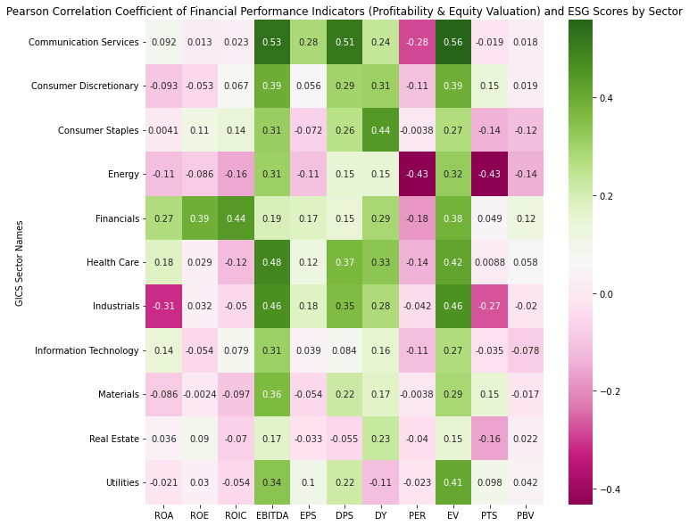

```python
fig,ax = plt.subplots(figsize=(10,10))
ax = sns.heatmap(new_ev_p, annot=True, cmap="PiYG")
ax.set_title("Pearson Correlation Coefficient of Financial Performance Indicators (Profitability & Equity Valuation) and ESG Scores by Sector")
```